# Identification of common variables

### Household size

Variable: hh_size

**Conclusion: similar distribution, but not in all countries**

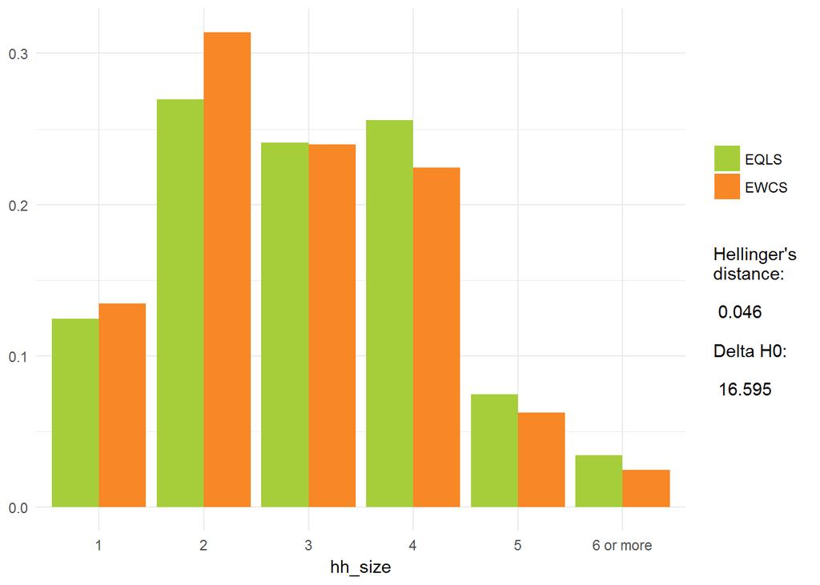

```r
EQLS$hh_size[EQLS$Y16_HH1==1] <- 1
EQLS$hh_size[EQLS$Y16_HH1==2] <- 2
EQLS$hh_size[EQLS$Y16_HH1==3] <- 3
EQLS$hh_size[EQLS$Y16_HH1==4] <- 4
EQLS$hh_size[EQLS$Y16_HH1==5] <- 5
EQLS$hh_size[EQLS$Y16_HH1>=6] <- 6

EWCS$hh_size[EWCS$y15_Q1=="1"] <- 1
EWCS$hh_size[EWCS$y15_Q1=="2"] <- 2
EWCS$hh_size[EWCS$y15_Q1=="3"] <- 3
EWCS$hh_size[EWCS$y15_Q1=="4"] <- 4
EWCS$hh_size[EWCS$y15_Q1=="5"] <- 5
EWCS$hh_size[EWCS$y15_Q1=="6 or more"] <- 6

EQLS$hh_size <- factor(EQLS$hh_size,levels=c(1:6),labels=c("1","2","3","4","5","6 or more"),ordered=T)
EWCS$hh_size <- factor(EWCS$hh_size,levels=c(1:6),labels=c("1","2","3","4","5","6 or more"),ordered=T)

HD(~hh_size,~hh_size,name="hh_size")
```

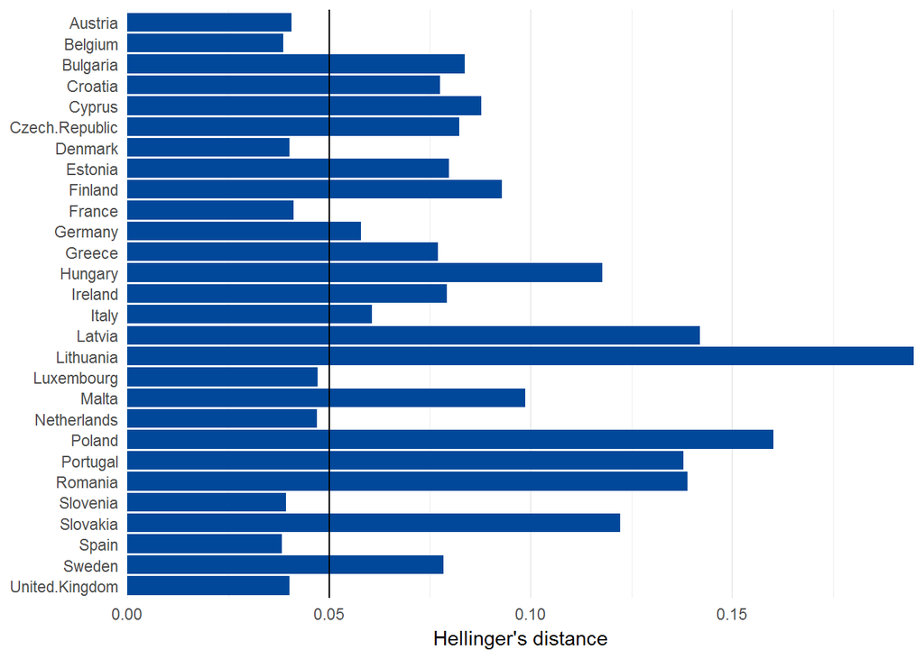

```r
Helld_country(~hh_size,~hh_size)
```

### Working hours of the partner

Variable: partner_hour (continuous) partner_hour_cat (categorical)

Note: this is missing for those without a partner

**Conclusion: similar distribution, with country differences**

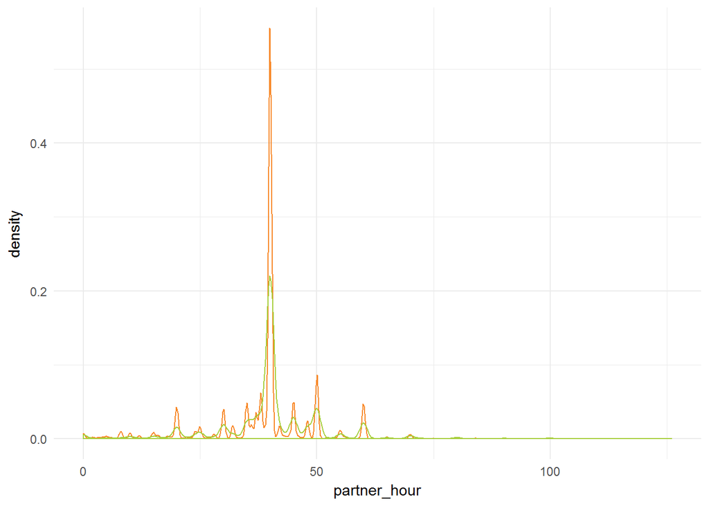

```r
EWCS$partner_hour <- as.numeric(levels(EWCS$y15_Q97))[EWCS$y15_Q97]
EQLS$partner_hour <- as.numeric(levels(EQLS$Y16_Q18))[EQLS$Y16_Q18]

ggplot() +
  geom_density(data=EWCS, aes(x=partner_hour), colour=EF_orange, na.rm=T) +
  geom_density(data=EQLS, aes(x=partner_hour), colour=EF_green, na.rm=T) +
  theme_minimal()
```

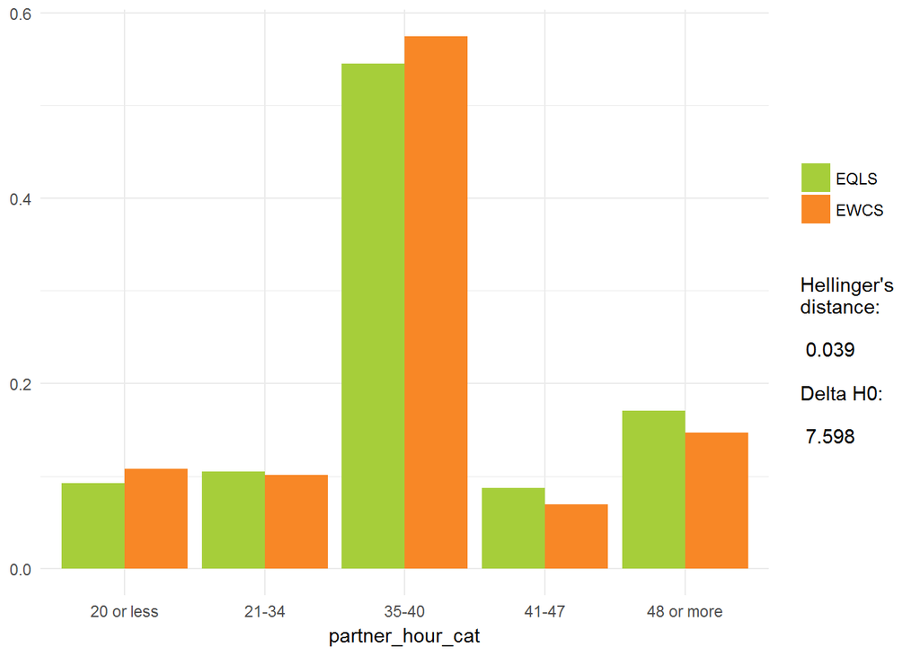

```r
EQLS$partner_hour_cat <- recode(EQLS$partner_hour,"lo:20='20 or less';21:34='21-34';35:40='35-40';41:47='41-47';48:hi='48 or more'",as.factor.result=TRUE,
                                                  levels = c('20 or less','21-34','35-40','41-47','48 or more'))
EWCS$partner_hour_cat <- recode(EWCS$partner_hour,"lo:20='20 or less';21:34='21-34';35:40='35-40';41:47='41-47';48:hi='48 or more'",as.factor.result=TRUE,
                                                  levels = c('20 or less','21-34','35-40','41-47','48 or more'))

HD(~partner_hour_cat, ~partner_hour_cat, name="partner_hour_cat")
```

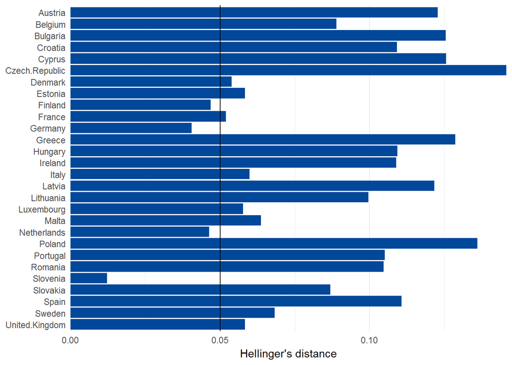

```r
Helld_country(~partner_hour_cat,~partner_hour_cat)
```

### General health

Variable gen_health

**Conclusion: same distribution with country differences**

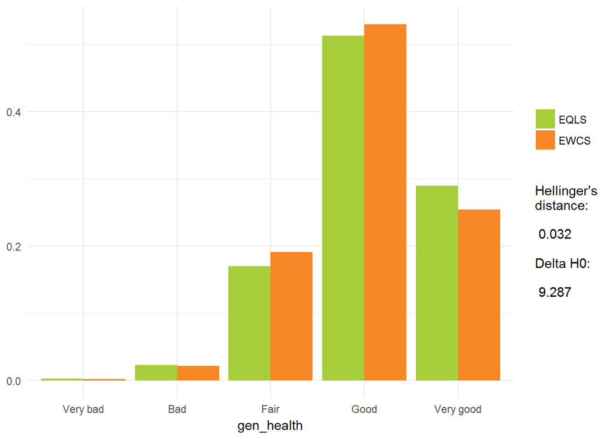

```r
EQLS$gen_health[EQLS$Y16_Q48=="Very bad    "] <- 0
EQLS$gen_health[EQLS$Y16_Q48=="Bad         "] <- 1
EQLS$gen_health[EQLS$Y16_Q48=="Fair        "] <- 2
EQLS$gen_health[EQLS$Y16_Q48=="Good        "] <- 3
EQLS$gen_health[EQLS$Y16_Q48=="Very good   "] <- 4

EWCS$gen_health[EWCS$y15_Q75=="Very bad                    "] <- 0
EWCS$gen_health[EWCS$y15_Q75=="Bad                         "] <- 1
EWCS$gen_health[EWCS$y15_Q75=="Fair                        "] <- 2
EWCS$gen_health[EWCS$y15_Q75=="Good                        "] <- 3
EWCS$gen_health[EWCS$y15_Q75=="Very good                   "] <- 4

EWCS$gen_health <- factor(EWCS$gen_health,levels=c(0:4),labels=c("Very bad","Bad","Fair","Good","Very good"),ordered=T)
EQLS$gen_health <- factor(EQLS$gen_health,levels=c(0:4),labels=c("Very bad","Bad","Fair","Good","Very good"),ordered=T)

HD(~gen_health,~gen_health,name="gen_health")
```

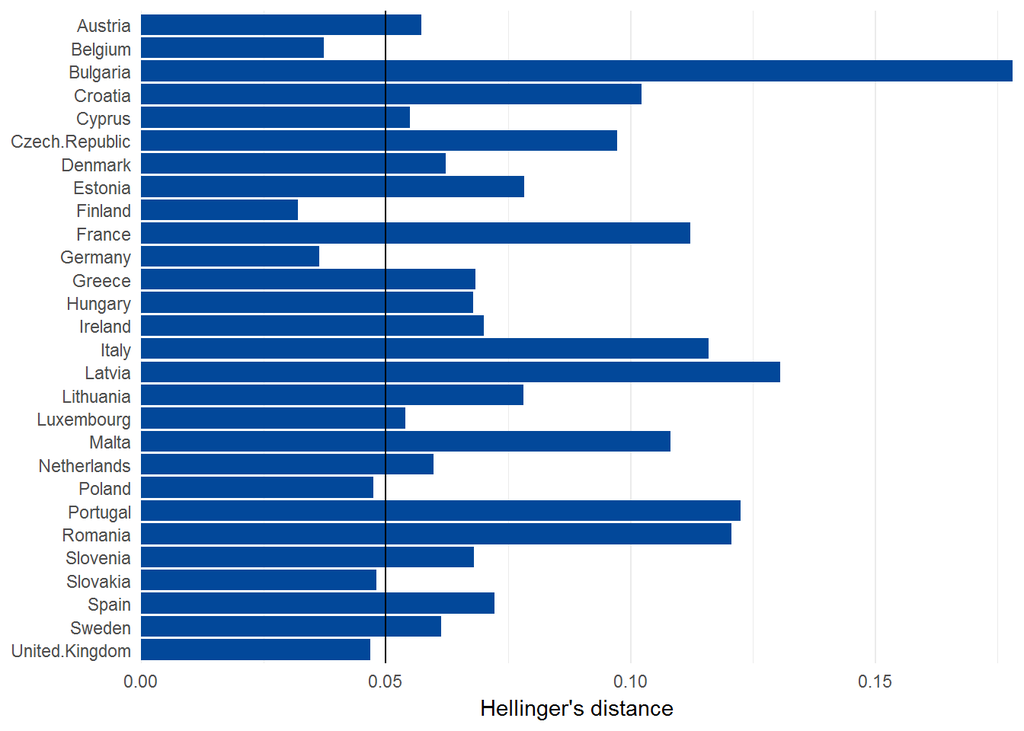

```r
Helld_country(~gen_health,~gen_health)
```

### WHO5

variable who5 (continuous)

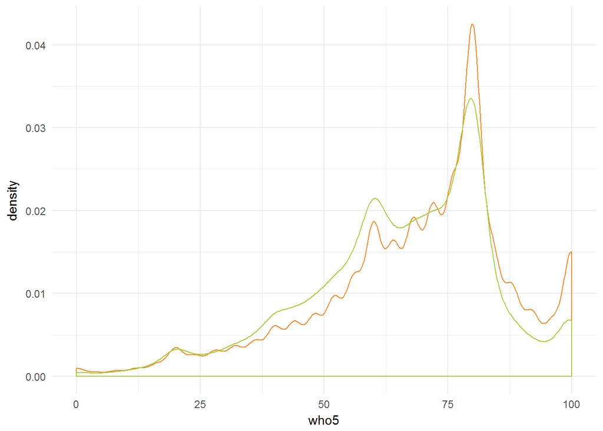

```r
EQLS$who5 <- EQLS$Y16_WHO5_MWIndex
EWCS$who5 <- EWCS$wellbeing

ggplot() +
  geom_density(data=EWCS, aes(x=who5), colour=EF_orange, na.rm=T) +
  geom_density(data=EQLS, aes(x=who5), colour=EF_green, na.rm=T) +
  theme_minimal()
```

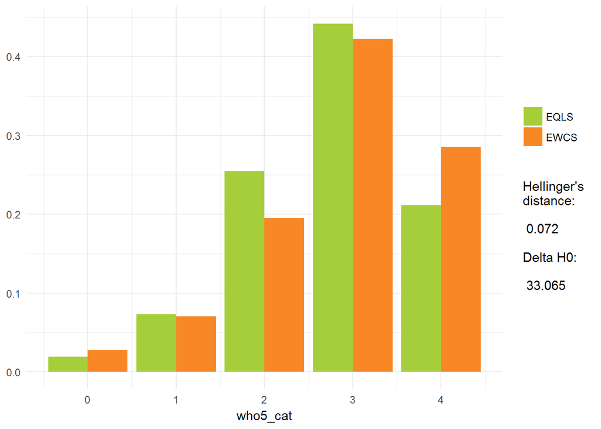

```r
EQLS$who5_cat[EQLS$who5<20] <- 0
EQLS$who5_cat[EQLS$who5>20 & EQLS$who5<40] <- 1
EQLS$who5_cat[EQLS$who5>40 & EQLS$who5<60] <- 2
EQLS$who5_cat[EQLS$who5>60 & EQLS$who5<80] <- 3
EQLS$who5_cat[EQLS$who5>80] <- 4

EWCS$who5_cat[EWCS$who5<20] <- 0
EWCS$who5_cat[EWCS$who5>20 & EWCS$who5<40] <- 1
EWCS$who5_cat[EWCS$who5>40 & EWCS$who5<60] <- 2
EWCS$who5_cat[EWCS$who5>60 & EWCS$who5<80] <- 3
EWCS$who5_cat[EWCS$who5>80] <- 4

HD(~who5_cat,~who5_cat,name="who5_cat")
```

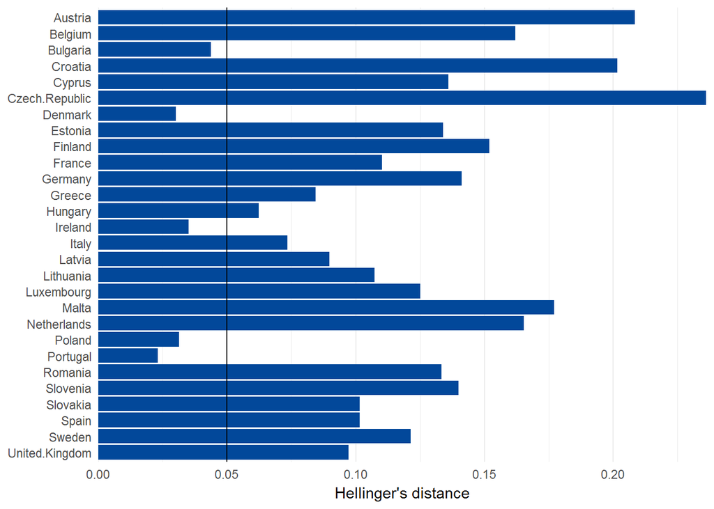

```r
Helld_country(~who5_cat,~who5_cat)
```

### Commuting time

Variable commute_time (continuous)

**Conclusion: very similar distribution**

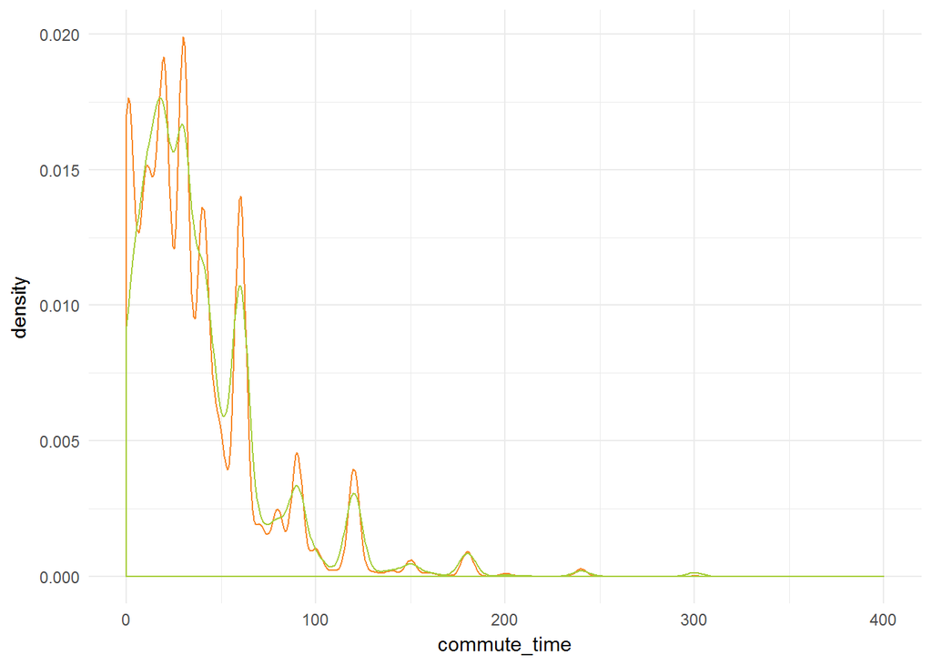

```r
EWCS$commute_time <- EWCS$y15_Q36
EWCS$commute_time <- as.numeric(levels(EWCS$commute_time))[EWCS$commute_time]
EWCS$commute_time[is.na(EWCS$commute_time)] <- 0

EQLS$commute_time <- EQLS$Y16_Q57
EQLS$commute_time <- as.numeric(levels(EQLS$commute_time))[EQLS$commute_time]

ggplot() +
  geom_density(data=EWCS, aes(x=commute_time), colour=EF_orange, na.rm=T) +
  geom_density(data=EQLS, aes(x=commute_time), colour=EF_green, na.rm=T) +
  theme_minimal()
```

### Education

variable: education_3cat

Note: this variable would also be available with more categories, but some categories are quite small

**Conclusion: same distribution**

Very big difference in Austria for some reason

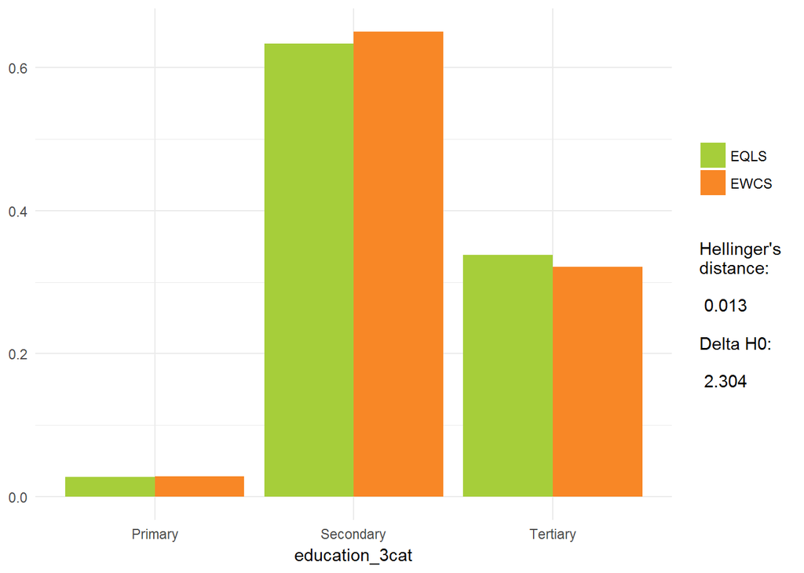

```r
EQLS$education_3cat[EQLS$education_traditional_3cat=="Primary"]   <- 1
EQLS$education_3cat[EQLS$education_traditional_3cat=="Secondary"] <- 2
EQLS$education_3cat[EQLS$education_traditional_3cat=="Tertiary"]  <- 3

EWCS$education_3cat[EWCS$education=="primary"]   <- 1
EWCS$education_3cat[EWCS$education=="secondary"] <- 2
EWCS$education_3cat[EWCS$education=="tertiary"]  <- 3

EWCS$education_3cat <- factor(EWCS$education_3cat,levels=c(1:3),labels=c("Primary","Secondary","Tertiary"),ordered=T)
EQLS$education_3cat <- factor(EQLS$education_3cat,levels=c(1:3),labels=c("Primary","Secondary","Tertiary"),ordered=T)

HD(~education_3cat,~education_3cat,name="education_3cat")
```

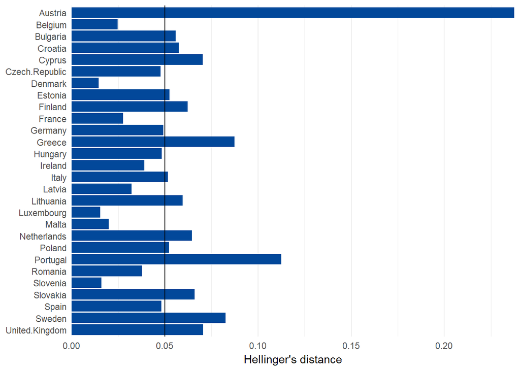

```r
Helld_country(~education_3cat,~education_3cat)
```

### Making ends meet

Variable: make_ends_meet

**Conclusion: same distribution, with country differences**

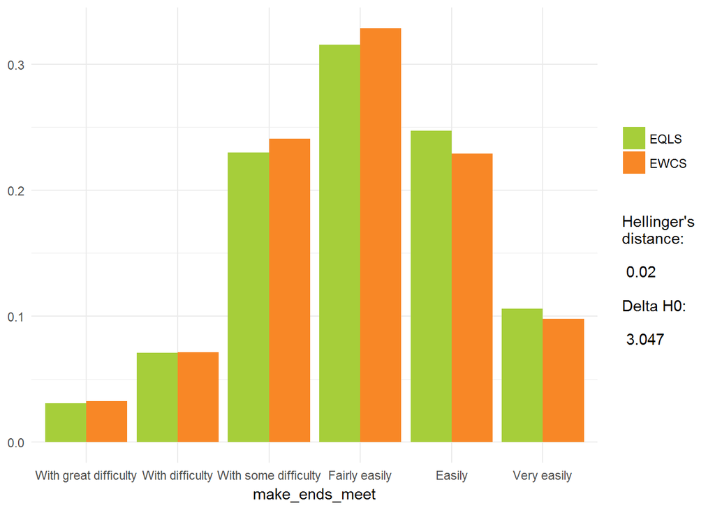

```r
EQLS$make_ends_meet[EQLS$Y16_Q88=="With great difficulty"] <- 0
EQLS$make_ends_meet[EQLS$Y16_Q88=="With difficulty      "] <- 1
EQLS$make_ends_meet[EQLS$Y16_Q88=="With some difficulty "] <- 2
EQLS$make_ends_meet[EQLS$Y16_Q88=="Fairly easily        "] <- 3
EQLS$make_ends_meet[EQLS$Y16_Q88=="Easily               "] <- 4
EQLS$make_ends_meet[EQLS$Y16_Q88=="Very easily          "] <- 5

EWCS$make_ends_meet[EWCS$y15_Q100=="With great difficulty       "] <- 0
EWCS$make_ends_meet[EWCS$y15_Q100=="With difficulty             "] <- 1
EWCS$make_ends_meet[EWCS$y15_Q100=="With some difficulty        "] <- 2
EWCS$make_ends_meet[EWCS$y15_Q100=="Fairly easily               "] <- 3
EWCS$make_ends_meet[EWCS$y15_Q100=="Easily                      "] <- 4
EWCS$make_ends_meet[EWCS$y15_Q100=="Very easily                 "] <- 5

EWCS$make_ends_meet <- factor(EWCS$make_ends_meet,levels=c(0:5),labels=c("With great difficulty","With difficulty","With some difficulty","Fairly easily","Easily","Very easily"),ordered=T)
EQLS$make_ends_meet <- factor(EQLS$make_ends_meet,levels=c(0:5),labels=c("With great difficulty","With difficulty","With some difficulty","Fairly easily","Easily","Very easily"),ordered=T)

HD(~make_ends_meet,~make_ends_meet,name="make_ends_meet")
```

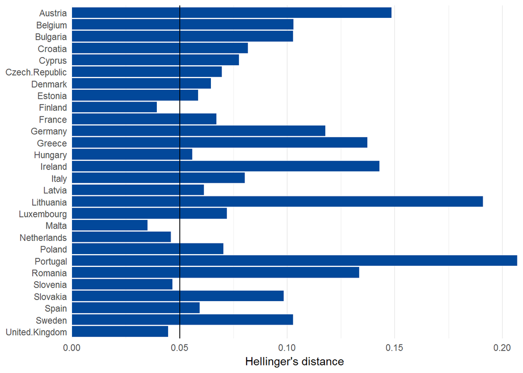

```r
Helld_country(~make_ends_meet,~make_ends_meet)
```

### Migrant

variable migrant

**Conclusion: similar distribution with country differences**

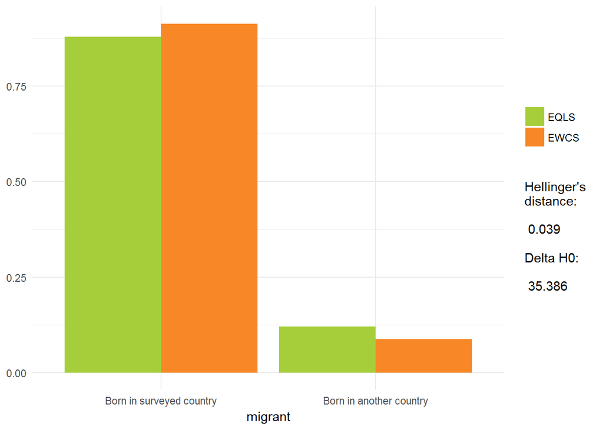

```r
EWCS$migrant[EWCS$y15_Q4b=="No                          "] <- 1
EWCS$migrant[EWCS$y15_Q4a=="Yes                         "] <- 0

EQLS$migrant[EQLS$firstgen_migrant=="Born in surveyed country"] <- 0
EQLS$migrant[EQLS$firstgen_migrant=="Born in another country"] <- 1

EQLS$migrant <- factor(EQLS$migrant,levels=c(0:1),labels=c("Born in surveyed country","Born in another country"),ordered=F)
EWCS$migrant <- factor(EWCS$migrant,levels=c(0:1),labels=c("Born in surveyed country","Born in another country"),ordered=F)

HD(~migrant,~migrant,name="migrant")
```

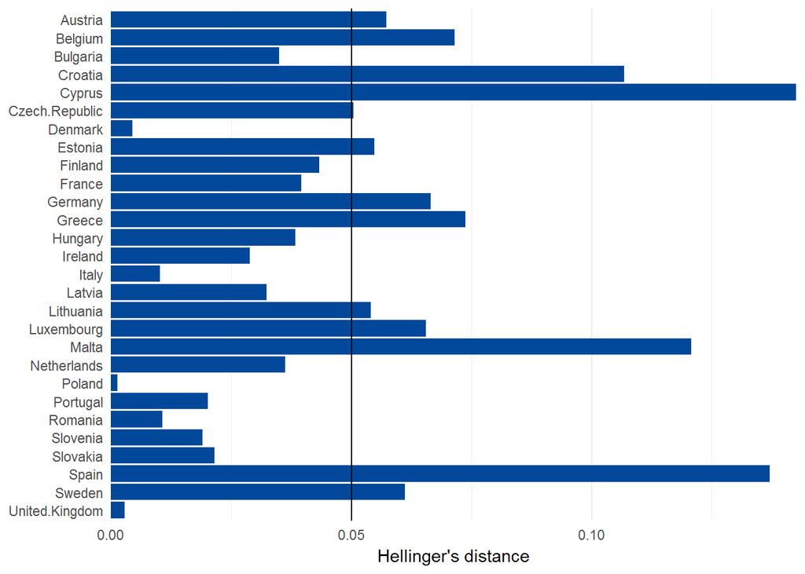

```r
Helld_country(~migrant,~migrant)
```

### Work-life balance

Variable: WorkLB

The question is identical between both surveys, but the categories are slightly different. In EQLS the two middle categories are “Rather not well” and “Rather well”, while in EWCS this is “Not very well” and “Well”.

The distributions show some differences but it seems reasonable to assume the categories are equivalent.

**Conclusion: same distribution, but country differences**

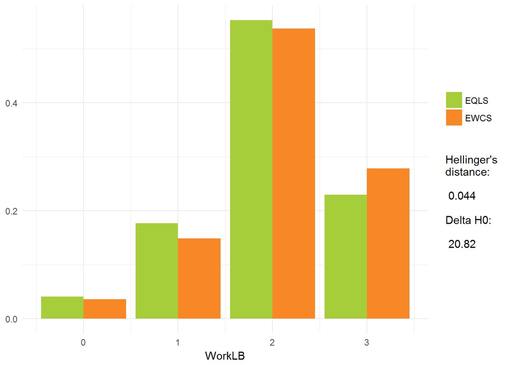

```r
EQLS$WorkLB[EQLS$Y16_Q19=="Not at all well"] <- 0
EQLS$WorkLB[EQLS$Y16_Q19=="Rather not well"] <- 1
EQLS$WorkLB[EQLS$Y16_Q19=="Rather well"] <- 2
EQLS$WorkLB[EQLS$Y16_Q19=="Very well"] <- 3

EWCS$WorkLB[EWCS$y15_Q44=="Not at all well             "] <- 0
EWCS$WorkLB[EWCS$y15_Q44=="Not very well               "] <- 1
EWCS$WorkLB[EWCS$y15_Q44=="Well                        "] <- 2
EWCS$WorkLB[EWCS$y15_Q44=="Very well                   "] <- 3

EQLS$WorkLB <- factor(EQLS$WorkLB,levels=c(0:3),ordered=T)
EWCS$WorkLB <- factor(EWCS$WorkLB,levels=c(0:3),ordered=T)

HD(~WorkLB,~WorkLB,"WorkLB")
```

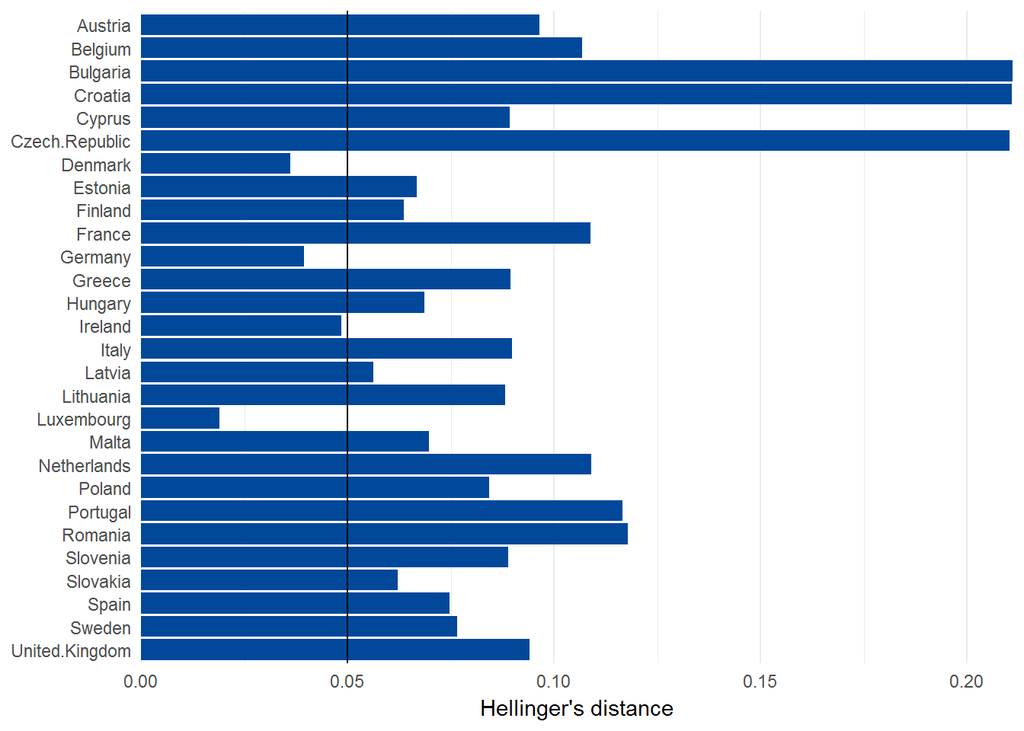

```r
Helld_country(~WorkLB,~WorkLB)
```

### Work-life reconciliation

Variables too_tired fam_resp concentrate

Questions on work-life reconciliation are very similar:

EWCS: How often in the last 12 months, have you…?

1. felt too tired after work to do some of the household jobs which need to be done
2. found that your job prevented you from giving the time you wanted to your family
3. found it difficult to concentrate on your job because of your family responsibilities

EQLS: How often has each of the following happened to you during the last 12 months?

1. I have come home from work too tired to do some of the household jobs which need to be done
2. It has been difficult for me to fulfil my family responsibilities because of the amount of time I spend on the job
3. I have found it difficult to concentrate at work because of my family responsibilities

But the scale is different: EWCS: Always – Most of the time – Sometimes – Rarely – Never EQLS: Every day – Several times a week – Several times a month – Several times a year – Less often/rarely - Never

**Conclusion: not the same distribution. Not suitable for matching**

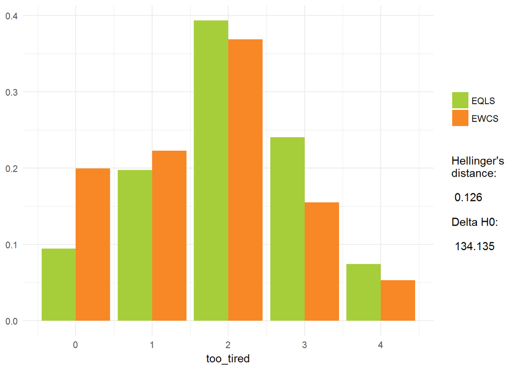

```r
EWCS$too_tired[EWCS$y15_Q45b=="Never                        "] <- 0
EWCS$too_tired[EWCS$y15_Q45b=="Rarely                       "] <- 1
EWCS$too_tired[EWCS$y15_Q45b=="Sometimes                    "] <- 2
EWCS$too_tired[EWCS$y15_Q45b=="Most of the time             "] <- 3
EWCS$too_tired[EWCS$y15_Q45b=="Always                       "] <- 4

EQLS$too_tired[EQLS$Y16_Q20a=="Never"] <- 0
EQLS$too_tired[EQLS$Y16_Q20a=="Less often/rarely"] <- 1
EQLS$too_tired[EQLS$Y16_Q20a=="Several times a year"] <- 2
EQLS$too_tired[EQLS$Y16_Q20a=="Several times a month"] <- 2
EQLS$too_tired[EQLS$Y16_Q20a=="Several times a week"] <- 3
EQLS$too_tired[EQLS$Y16_Q20a=="Every day (option added in 4th EQLS)"] <- 4

HD(~too_tired, ~too_tired, name="too_tired")
```

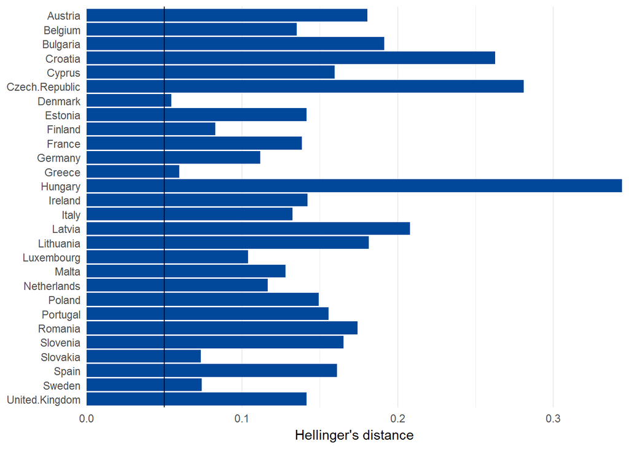

```r
Helld_country(~too_tired, ~too_tired)
```

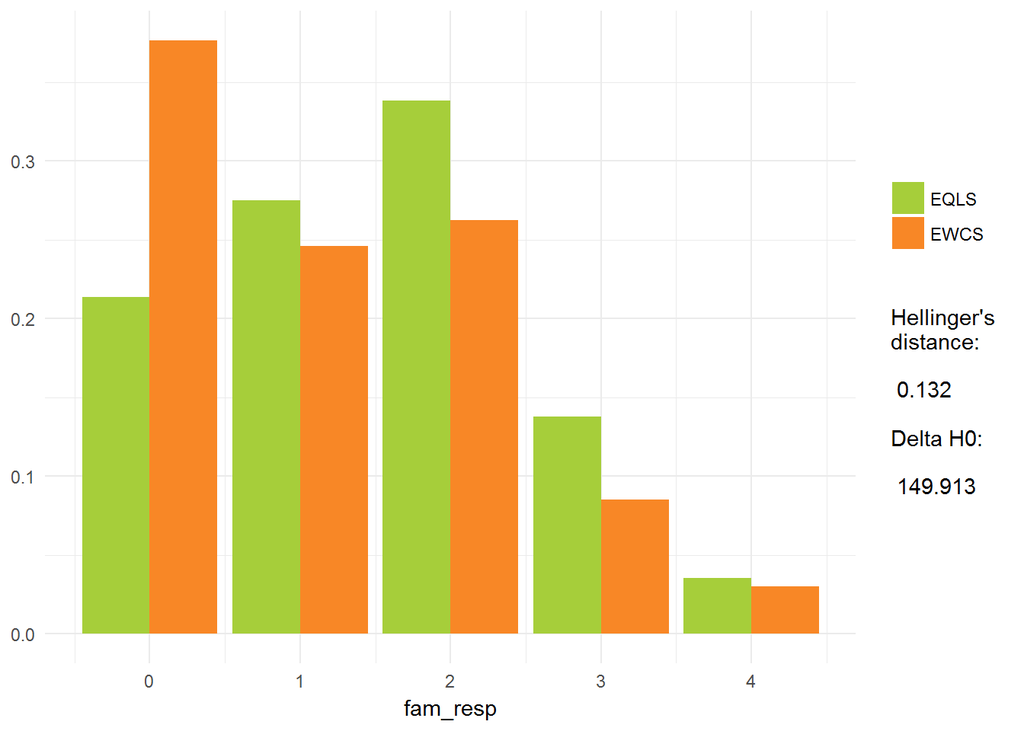

```r
EWCS$fam_resp[EWCS$y15_Q45c=="Never                        "] <- 0
EWCS$fam_resp[EWCS$y15_Q45c=="Rarely                       "] <- 1
EWCS$fam_resp[EWCS$y15_Q45c=="Sometimes                    "] <- 2
EWCS$fam_resp[EWCS$y15_Q45c=="Most of the time             "] <- 3
EWCS$fam_resp[EWCS$y15_Q45c=="Always                       "] <- 4

EQLS$fam_resp[EQLS$Y16_Q20b=="Never"] <- 0
EQLS$fam_resp[EQLS$Y16_Q20b=="Less often/rarely"] <- 1
EQLS$fam_resp[EQLS$Y16_Q20b=="Several times a year"] <- 2
EQLS$fam_resp[EQLS$Y16_Q20b=="Several times a month"] <- 2
EQLS$fam_resp[EQLS$Y16_Q20b=="Several times a week"] <- 3
EQLS$fam_resp[EQLS$Y16_Q20b=="Every day (option added in 4th EQLS)"] <- 4

HD(~fam_resp, ~fam_resp, name="fam_resp")
```

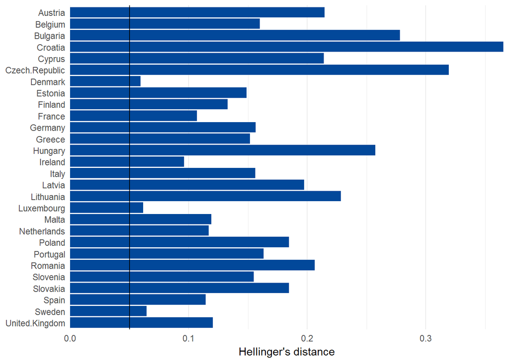

```r
Helld_country(~fam_resp, ~fam_resp)
```

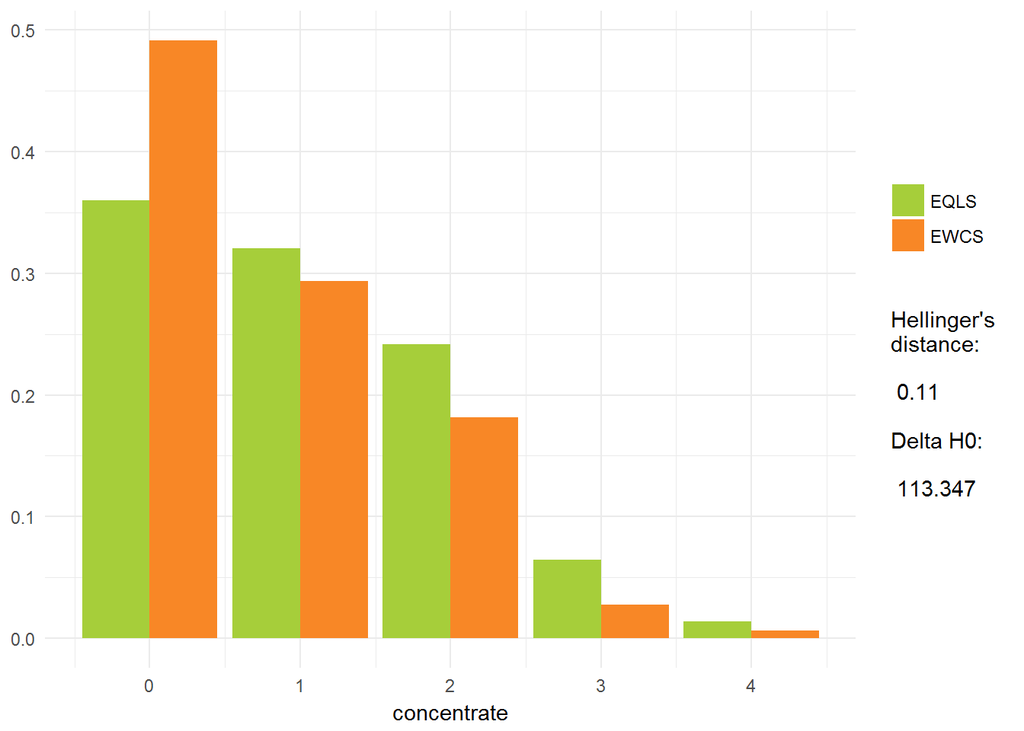

```r
EWCS$concentrate[EWCS$y15_Q45d=="Never                        "] <- 0
EWCS$concentrate[EWCS$y15_Q45d=="Rarely                       "] <- 1
EWCS$concentrate[EWCS$y15_Q45d=="Sometimes                    "] <- 2
EWCS$concentrate[EWCS$y15_Q45d=="Most of the time             "] <- 3
EWCS$concentrate[EWCS$y15_Q45d=="Always                       "] <- 4

EQLS$concentrate[EQLS$Y16_Q20c=="Never"] <- 0
EQLS$concentrate[EQLS$Y16_Q20c=="Less often/rarely"] <- 1
EQLS$concentrate[EQLS$Y16_Q20c=="Several times a year"] <- 2
EQLS$concentrate[EQLS$Y16_Q20c=="Several times a month"] <- 2
EQLS$concentrate[EQLS$Y16_Q20c=="Several times a week"] <- 3
EQLS$concentrate[EQLS$Y16_Q20c=="Every day (option added in 4th EQLS)"] <- 4

HD(~concentrate, ~concentrate, name="concentrate")
```

```r
#Helld_country(~concentrate, ~concentrate) -- not all countries have all categories
```

### Might lose job

Variable: mightlose

Wording of the question is nearly the same: EWCS: To what extent do you agree or disagree with the following statements about your job? I might lose my job in the next 6 months EQLS: Using this scale, how likely or unlikely do you think it is that you might lose your job in the next 6 months?

But the scales are different. EWCS: strongly disagree, tend to disagree, neither agree nor disagree, tend to agree, strongly agree EQLS: very unlikely, rather unlikely, neither likely nor unlikely, rather likely, very likely.

Distributions are different, which might be the result of the different wording of the scale.

**Conclusion: disributions not the same**

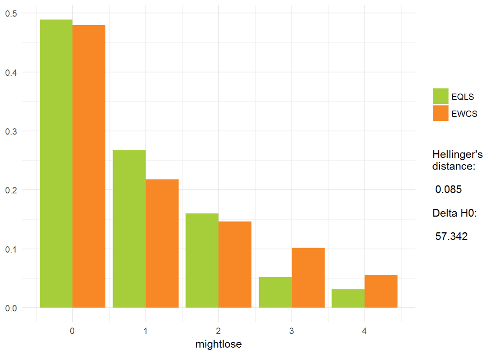

```r
EWCS$mightlose[EWCS$y15_Q89g=="Strongly disagree           "] <- 0
EWCS$mightlose[EWCS$y15_Q89g=="Tend to disagree            "] <- 1
EWCS$mightlose[EWCS$y15_Q89g=="Neither agree nor disagree  "] <- 2
EWCS$mightlose[EWCS$y15_Q89g=="Tend to agree               "] <- 3
EWCS$mightlose[EWCS$y15_Q89g=="Strongly agree              "] <- 4

EQLS$mightlose[EQLS$Y16_Q21=="Very unlikely"] <- 0
EQLS$mightlose[EQLS$Y16_Q21=="Rather unlikely"] <- 1
EQLS$mightlose[EQLS$Y16_Q21=="Neither likely nor unlikely"] <- 2
EQLS$mightlose[EQLS$Y16_Q21=="Rather likely"] <- 3
EQLS$mightlose[EQLS$Y16_Q21=="Very likely"] <- 4

HD(~mightlose, ~mightlose, name="mightlose")
```

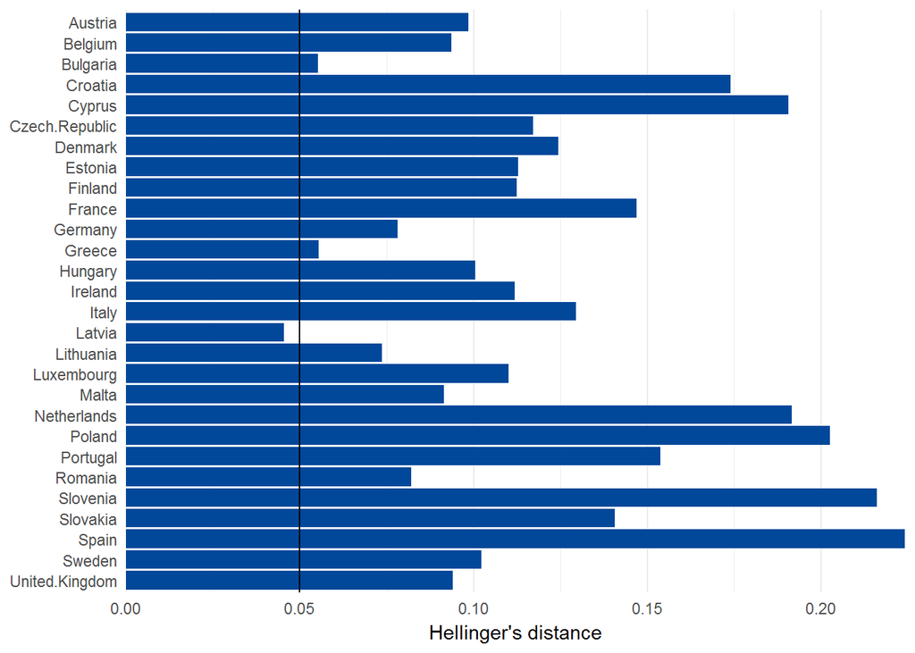

```r
Helld_country(~mightlose, ~mightlose)
```

### Find new job

Variable: findnewjob

Similar to the previous item, the question is nearly identical EWCS: If I were to lose or quit my current job, it would be easy for me to find a job of similar salary EQLS: If you were to lose or had to quit your job, how likely or unlikely is it that you will find a job of similar salary?

But the scales are different EWCS: strongly disagree, tend to disagree, neither agree nor disagree, tend to agree, strongly agree EQLS: very unlikely, rather unlikely, neither likely nor unlikely, rather likely, very likely.

Distribution is not that far off, but there are some differences

**Conclusion: not the same distribution. Perhaps with more tests we could be more certain**

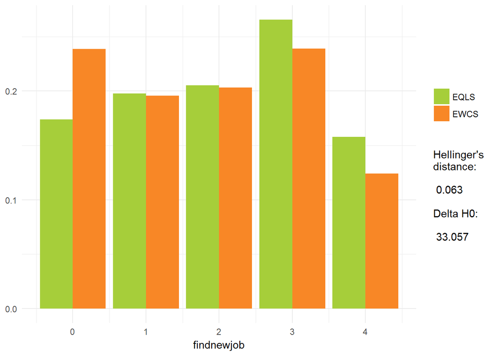

```r
EWCS$findnewjob[EWCS$y15_Q89h=="Strongly disagree           "] <- 0
EWCS$findnewjob[EWCS$y15_Q89h=="Tend to disagree            "] <- 1
EWCS$findnewjob[EWCS$y15_Q89h=="Neither agree nor disagree  "] <- 2
EWCS$findnewjob[EWCS$y15_Q89h=="Tend to agree               "] <- 3
EWCS$findnewjob[EWCS$y15_Q89h=="Strongly agree              "] <- 4

EQLS$findnewjob[EQLS$Y16_Q22=="Very unlikely"] <- 0
EQLS$findnewjob[EQLS$Y16_Q22=="Rather unlikely"] <- 1
EQLS$findnewjob[EQLS$Y16_Q22=="Neither likely nor unlikely"] <- 2
EQLS$findnewjob[EQLS$Y16_Q22=="Rather likely"] <- 3
EQLS$findnewjob[EQLS$Y16_Q22=="Very likely"] <- 4

HD(~findnewjob, ~findnewjob, name="findnewjob")
```

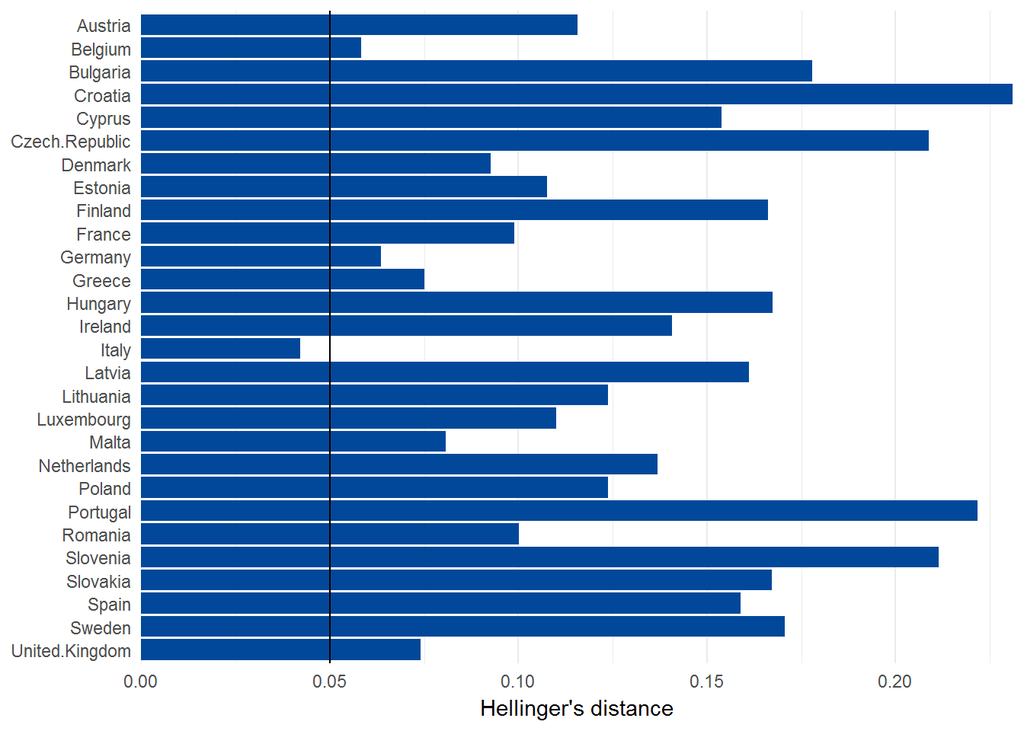

```r
Helld_country(~findnewjob, ~findnewjob)
```

### Care for children

Variable: care_child_grandchild

EQLS Q42a: Caring for and/or educating your children Q42b: Caring for and/or educating your grandchildren

EWCS Caring for and/or educating your children, grandchildren

EQLS range: Every day, several days a week, once or twice a week, less often, never EWCS range: Daily, Several times a week, several times a month, less often, never.

The EWCS asks the question to everybody, with the option of respondent ‘not applicable’ The EQLS asks

- the question about children only to those with children under 18 in the household or not in the household
- the question about grabdchildren only to those with children over 18 or grandchildren in the household or children not in the household.

The issue with the split question in the EQLS vis a vis the EWCS is that in the EQLS you could for example say ‘once or twice a week’ for both the children and the grandchildren. Would that be equivalent to several days a week? Hard to say.

Assuming that the not applicables in the EWCS and the system missings in EQLS are equivalent to never, we get distributions which are only roughly the same. Given the differences in questions, scales and differences in selection, we should not consider these as coherent. There is also a lot of difference in the ‘never’ category.

**Conclusion: distributions and measurement are too different**

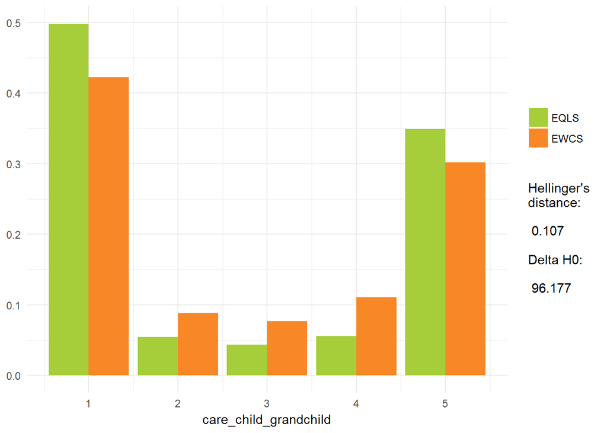

```r
EQLS$q42a_nev <- (EQLS$Y16_Q42a=="Never" | EQLS$Y16_Q42a=="Not applicable" | is.na(EQLS$Y16_Q42a))
EQLS$q42b_nev <- (EQLS$Y16_Q42b=="Never" | EQLS$Y16_Q42b=="Not applicable" | is.na(EQLS$Y16_Q42b))

EQLS$care_child_grandchild[EQLS$q42a_nev==T & EQLS$q42b_nev==T] <- 1
EQLS$care_child_grandchild[EQLS$Y16_Q42a=="Less often" | EQLS$Y16_Q42b=="Less often"] <- 2
EQLS$care_child_grandchild[EQLS$Y16_Q42a=="Once or twice a week" | EQLS$Y16_Q42b=="Once or twice a week"] <- 3
EQLS$care_child_grandchild[EQLS$Y16_Q42a=="Several days a week" | EQLS$Y16_Q42b=="Several days a week"] <- 4
EQLS$care_child_grandchild[EQLS$Y16_Q42a=="Every day" | EQLS$Y16_Q42b=="Every day"] <- 5

EWCS$care_child_grandchild[EWCS$y15_Q95c=="Never                       " | EWCS$y15_Q95c=="Not applicable (spontaneous)"] <- 1
EWCS$care_child_grandchild[EWCS$y15_Q95c=="Less often                  "] <- 2
EWCS$care_child_grandchild[EWCS$y15_Q95c=="Several times a month       "] <- 3
EWCS$care_child_grandchild[EWCS$y15_Q95c=="Several times a week        "] <- 4
EWCS$care_child_grandchild[EWCS$y15_Q95c=="Daily                       "] <- 5

HD(~care_child_grandchild, ~care_child_grandchild, name="care_child_grandchild")
```

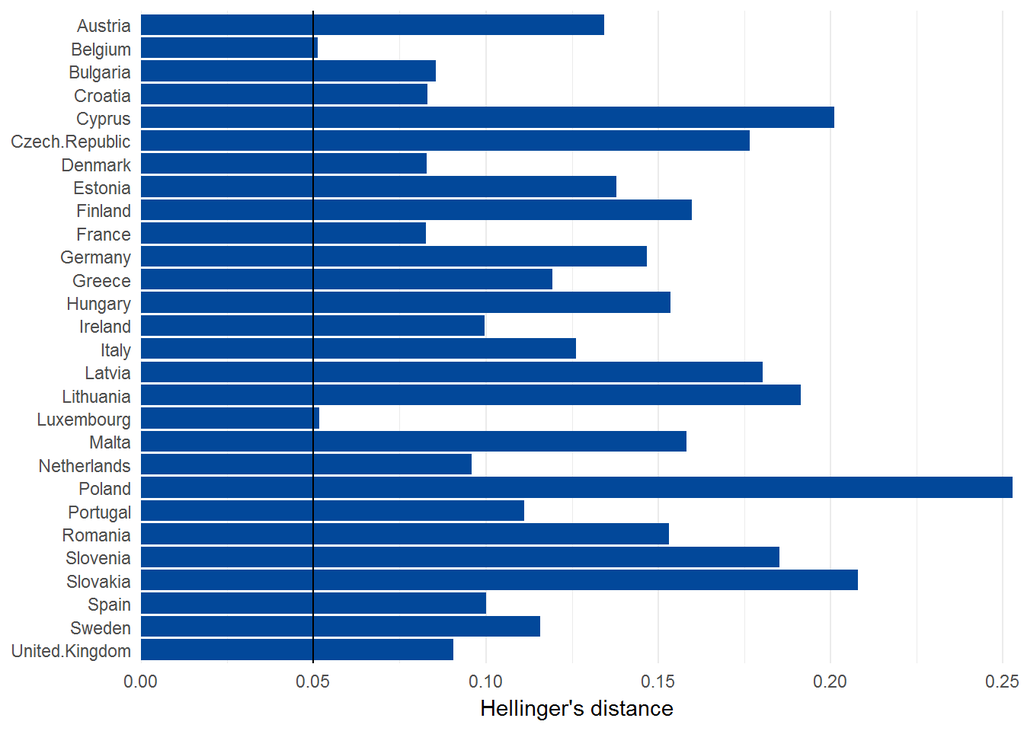

```r
Helld_country(~care_child_grandchild, ~care_child_grandchild)
```

### Caring for relatives

Variable: care_disabled

Also here the resopndent might be talking about a relative younger than 75 years old and a relative older than 75 years old at the same time. We assume that this is negligable.

**Conclusion: same distribution**

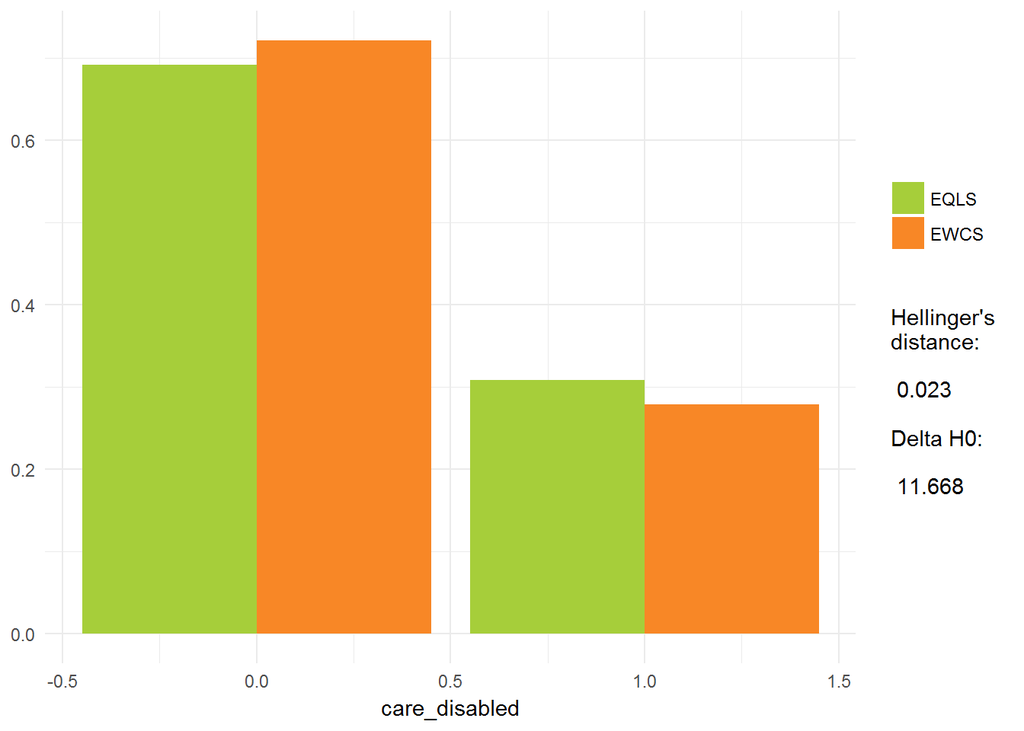

```r
EQLS$Q42d_nev <- EQLS$Y16_Q42d=="Never" | EQLS$Y16_Q42d=="Not applicable"
EQLS$Q42e_nev <- EQLS$Y16_Q42e=="Never" | EQLS$Y16_Q42e=="Not applicable"

EQLS$care_disabled[EQLS$Q42d_nev==T & EQLS$Q42e_nev==T ] <- 0
EQLS$care_disabled[EQLS$Y16_Q42d=="Less often" | EQLS$Y16_Q42e=="Less often"] <- 1
EQLS$care_disabled[EQLS$Y16_Q42d=="Once or twice a week" | EQLS$Y16_Q42e=="Once or twice a week"] <- 1
EQLS$care_disabled[EQLS$Y16_Q42d=="Several days a week" | EQLS$Y16_Q42e=="Several days a week"] <- 1
EQLS$care_disabled[EQLS$Y16_Q42d=="Every day" | EQLS$Y16_Q42e=="Every day"] <- 1

EWCS$care_disabled[EWCS$y15_Q95e=="Never                       "] <- 0
EWCS$care_disabled[EWCS$y15_Q95e=="Less often                  "] <- 1
EWCS$care_disabled[EWCS$y15_Q95e=="Several times a month       "] <- 1
EWCS$care_disabled[EWCS$y15_Q95e=="Several times a week        "] <- 1
EWCS$care_disabled[EWCS$y15_Q95e=="Daily                       "] <- 1

HD(~care_disabled, ~care_disabled, name="care_disabled")
```

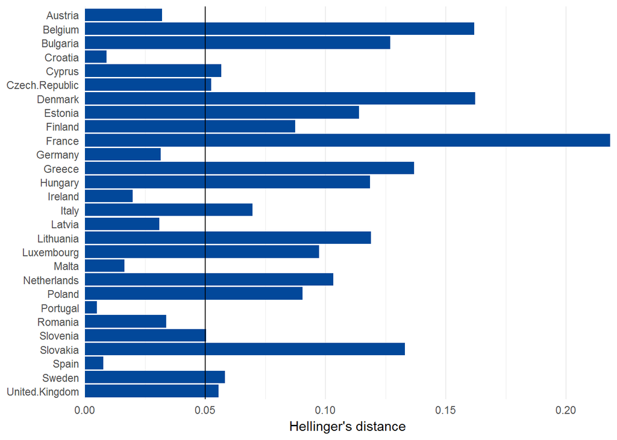

```r
Helld_country(~care_disabled, ~care_disabled)
```

```r
save(EQLS,file="EQLS.Rda")
save(EWCS,file="EWCS.Rda")
```

# Correlations

## Correlations between continuous variables

Despite the same or different distributions, the joint distributions of the common variables could differ between the surveys. For continuous variables, differences in correlations between the surveys may be a sign of differences in measurement. For practical reasons, ordinal variables are considered as being continuous for this analysis.

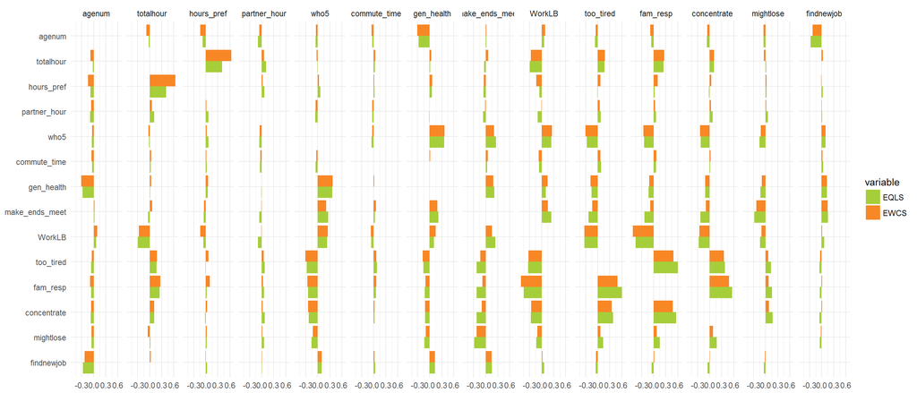

```r
c_vars <- c("agenum","totalhour","hours_pref","partner_hour","who5","commute_time","gen_health","make_ends_meet","WorkLB","too_tired","fam_resp","concentrate","mightlose","findnewjob")

c <- subset(EQLS,select=c_vars)
c <- data.frame(lapply(c, function(x) as.numeric(x)))
c <- as.data.frame(cor(c,use="pairwise.complete.obs"))
c$var.x <- rownames(c)
c_EQLS <- melt(c, id.vars="var.x", variable.name="var.y", value.name="EQLS")

c <- subset(EWCS,select=c_vars)
c <- data.frame(lapply(c, function(x) as.numeric(x)))
c <- as.data.frame(cor(c,use="pairwise.complete.obs"))
c$var.x <- rownames(c)
c_EWCS <- melt(c, id.vars="var.x", variable.name="var.y", value.name="EWCS")

c <- cbind(c_EQLS,subset(c_EWCS,select="EWCS"))
c <- melt(c, id.vars=c("var.x","var.y"))
c$value[c$value==1] <- NA
c <- c[order(c$var.x,c$var.y),]
c$var.x <- factor(c$var.x,levels=c_vars)
c$var.y <- factor(c$var.y,levels=c_vars)

ggplot(c, aes(x=var.x,y=value,fill=variable)) +
scale_x_discrete(limits = rev(levels(c$var.x))) +
facet_wrap(~var.y,nrow=1) +
scale_fill_manual(values=EF_2c2) +
coord_flip() +
geom_bar(stat="identity", position="dodge") +
theme_minimal() +
theme(axis.title=element_blank())
```

Correlations between the variables are generally quite small, but have the same sign and are generally comparable in terms of size. This also holds for those variables that do not have the same distribution in EWCS and EQLS

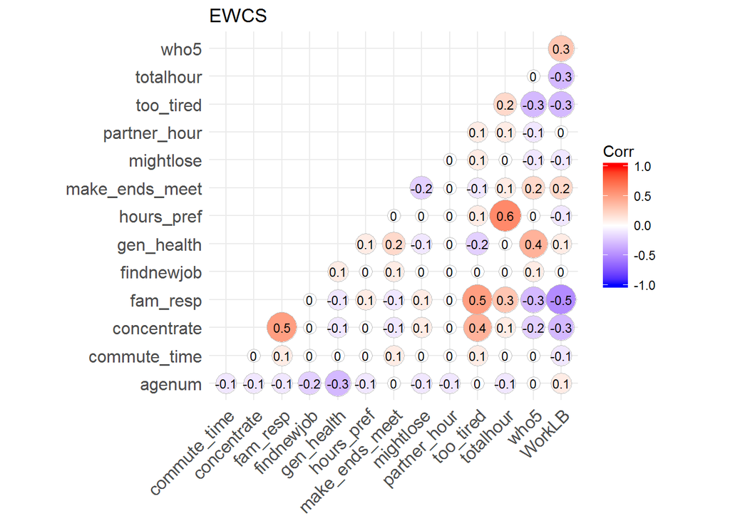

```r
df <- subset(EWCS, select=c_vars)
df <- data.frame(lapply(df, function(x) as.numeric(x)))
corr_EWCS <- round(cor(df,use="pairwise.complete.obs"),1)
corr_EWCS <- corr_EWCS[order(c_vars) , order(c_vars)]

ggcorrplot(corr_EWCS, hc.order = F,
           type = "lower",
           lab = TRUE,
           lab_size = 3,
           method="circle",
           title="EWCS",
           ggtheme=theme_minimal)
```

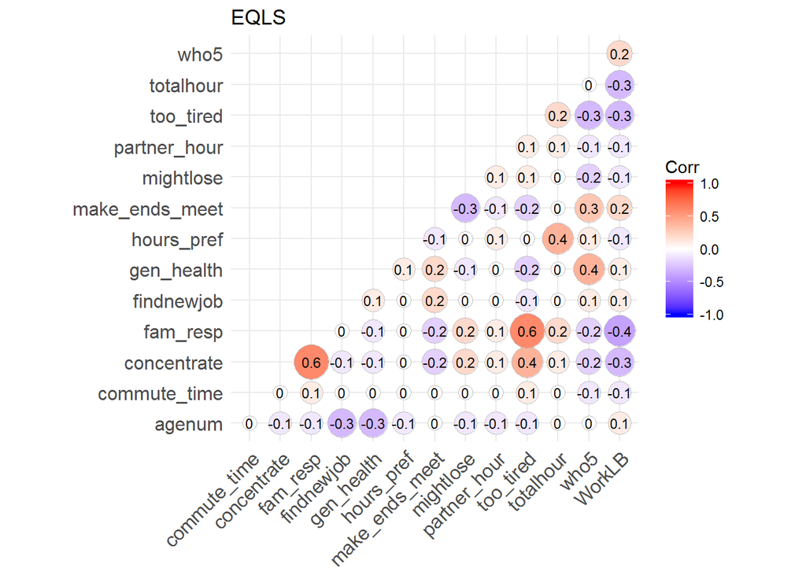

```r
df <- subset(EQLS, select=c_vars)
df <- data.frame(lapply(df, function(x) as.numeric(x)))
corr_EQLS <- round(cor(df,use="pairwise.complete.obs"),1)
corr_EQLS <- corr_EQLS[order(c_vars) , order(c_vars)]

ggcorrplot(corr_EQLS, hc.order = F,
           type = "lower",
           lab = TRUE,
           lab_size = 3,
           method="circle",
           title="EQLS",
           ggtheme=theme_minimal)
```

## Chi squared categorical variables

```r
define_svy()

n_vars <- c("Gender","empl_stat2","ISCO","partner_child","education_3cat","migrant","care_child_grandchild","care_disabled")
x <- combn(n_vars,m=2, simplify=T)
x <- t(x)
comb <- paste0(x[,1],"+",x[,2])

chisq_EQLS <- sapply(comb, FUN=function(combination) {svychisq(as.formula(paste0("~",combination)), EQLS_svyd, na.rm=TRUE)})
chisq_EQLS <- as.data.frame(chisq_EQLS)
chisq_EQLS <- chisq_EQLS[c("statistic","p.value"),]
chisq_EQLS <- as.data.frame(t(chisq_EQLS))
chisq_EQLS$var <- rownames(chisq_EQLS)
rownames(chisq_EQLS) <- NULL

chisq_EWCS <- sapply(comb, FUN=function(combination) {svychisq(as.formula(paste0("~",combination)), EWCS_svyd, na.rm=TRUE)})
chisq_EWCS <- as.data.frame(chisq_EWCS)
chisq_EWCS <- chisq_EWCS[c("statistic","p.value"),]
chisq_EWCS <- as.data.frame(t(chisq_EWCS))
chisq_EWCS$var <- rownames(chisq_EWCS)
rownames(chisq_EWCS) <- NULL
chisq_EWCS$survey <- "EWCS"

x <- cbind(chisq_EQLS[,1:3],chisq_EWCS[,1:2])
s_EQLS <- as.numeric(as.character(unlist(x[[1]])))
s_EWCS <- as.numeric(as.character(unlist(x[[4]])))
p_EQLS <- as.numeric(as.character(unlist(x[[2]])))
p_EWCS <- as.numeric(as.character(unlist(x[[5]])))
x <- data.frame(matrix(unlist(x[,3]), nrow=length(comb), byrow=F))
df <- as.data.frame(cbind(x,s_EQLS,p_EQLS,s_EWCS,p_EWCS))
colnames(df)[1] <- "var"

df$x <- df$s_EQLS/df$s_EWCS
df$p_EWCS_T <- p_EWCS<0.05
df$p_EQLS_T <- p_EQLS<0.05
df$dif <- df$p_EWCS_T!=df$p_EQLS_T | (df$p_EQLS_T==F | df$p_EWCS_T==F)

table(df$p_EWCS_T,df$p_EQLS_T)
```

```
##
##         FALSE TRUE
##   FALSE     2    0
##   TRUE      6   20
```

```r
df[,c("var","p_EWCS_T","p_EQLS_T")]
```

```
##                                     var p_EWCS_T p_EQLS_T
## 1                     Gender+empl_stat2     TRUE     TRUE
## 2                           Gender+ISCO     TRUE     TRUE
## 3                  Gender+partner_child     TRUE     TRUE
## 4                 Gender+education_3cat     TRUE     TRUE
## 5                        Gender+migrant    FALSE    FALSE
## 6          Gender+care_child_grandchild     TRUE     TRUE
## 7                  Gender+care_disabled     TRUE     TRUE
## 8                       empl_stat2+ISCO     TRUE     TRUE
## 9              empl_stat2+partner_child     TRUE     TRUE
## 10            empl_stat2+education_3cat     TRUE     TRUE
## 11                   empl_stat2+migrant     TRUE    FALSE
## 12     empl_stat2+care_child_grandchild     TRUE    FALSE
## 13             empl_stat2+care_disabled     TRUE    FALSE
## 14                   ISCO+partner_child     TRUE     TRUE
## 15                  ISCO+education_3cat     TRUE     TRUE
## 16                         ISCO+migrant     TRUE     TRUE
## 17           ISCO+care_child_grandchild     TRUE     TRUE
## 18                   ISCO+care_disabled     TRUE     TRUE
## 19         partner_child+education_3cat     TRUE     TRUE
## 20                partner_child+migrant     TRUE    FALSE
## 21  partner_child+care_child_grandchild     TRUE     TRUE
## 22          partner_child+care_disabled    FALSE    FALSE
## 23               education_3cat+migrant     TRUE     TRUE
## 24 education_3cat+care_child_grandchild     TRUE     TRUE
## 25         education_3cat+care_disabled     TRUE     TRUE
## 26        migrant+care_child_grandchild     TRUE    FALSE
## 27                migrant+care_disabled     TRUE    FALSE
## 28  care_child_grandchild+care_disabled     TRUE     TRUE
```

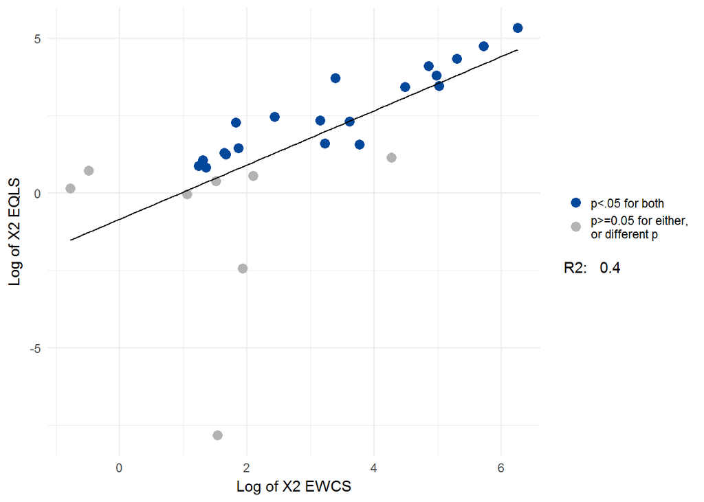

```r
ggplot(df, aes(x=log(s_EWCS),y=log(s_EQLS))) +
  geom_point(aes(colour=dif),size=3) +
  geom_smooth(method = "lm", se = F, colour="black", size=0.5) +
  scale_colour_manual(values=c(EF_blue,"grey70"),
                      name=paste("\nR2:  ", round(summary(lm(log(s_EQLS) ~ log(s_EWCS) , df))$r.squared,2)),
                      labels=c("p<.05 for both","p>=0.05 for either,\nor different p")) +
  guides(colour = guide_legend(title.position = "bottom")) +
  xlab("Log of X2 EWCS") +
  ylab("Log of X2 EQLS") +
  theme_minimal()
```

## Regressions continuous on categorical variables

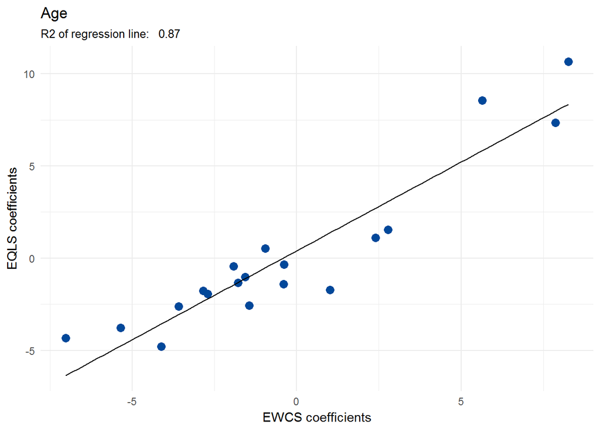

```r
n_vars_f <- c("Gender+empl_stat2+ISCO+partner_child+education_3cat+migrant+care_child_grandchild+care_disabled")

glm_EQLS <- lapply(c_vars, FUN=function(y) {summary(
                                              svyglm(
                                                paste0("as.numeric(",y,")~",n_vars_f),
                                                design=EQLS_svyd)
                                            )$coefficients})
names(glm_EQLS) <- c_vars

glm_EWCS <- lapply(c_vars, FUN=function(y) {summary(
                                              svyglm(
                                                paste0("as.numeric(",y,")~",n_vars_f),
                                                design=EWCS_svyd)
                                            )$coefficients})
names(glm_EWCS) <- c_vars

df <- as.data.frame(cbind(glm_EWCS$agenum[-1,1],glm_EQLS$agenum[-1,1]))
ggplot(df, aes(x=V1,y=V2)) +
  geom_point(size=3,colour=EF_blue) +
  geom_smooth(method = "lm", se = F, colour="black", size=0.5) +
   labs(title = "Age",
       subtitle = paste("R2 of regression line:  ", round(summary(lm(V2 ~ V1 , df))$r.squared,2)),
       x = "EWCS coefficients", y = "EQLS coefficients") +
    theme_minimal()
```

```r
kable(glm_EWCS$agenum,format="markdown")
```

|  | Estimate | Std. Error | t value | Pr(>\|t\|) |
| --- | --- | --- | --- | --- |
| (Intercept) | 46.9238740 | 0.6265435 | 74.893246 | 0.0000000 |
| GenderFemale | -0.3875104 | 0.2566219 | -1.510045 | 0.1311155 |
| empl_stat2employee | -4.1209204 | 0.3259226 | -12.643863 | 0.0000000 |
| ISCOProfessionals | -0.9500947 | 0.5138527 | -1.848963 | 0.0645410 |
| ISCOTechnicians and associate professionals | -1.5657744 | 0.5121428 | -3.057301 | 0.0022490 |
| ISCOClerical support workers | -1.9173544 | 0.5742654 | -3.338795 | 0.0008496 |
| ISCOService workers | -3.5905006 | 0.5467290 | -6.567240 | 0.0000000 |
| ISCOSales workers | -5.3457697 | 0.5625220 | -9.503220 | 0.0000000 |
| ISCOSkilled agricultural, forestry and fishery workers | 1.0187122 | 0.7691882 | 1.324399 | 0.1854504 |
| ISCOCraft and related trades workers | -2.8411577 | 0.5381870 | -5.279127 | 0.0000001 |
| ISCOPlant and machine operators and assemblers | -1.4389203 | 0.5774112 | -2.492020 | 0.0127443 |
| ISCOElementary occupations | -1.7851674 | 0.5267975 | -3.388717 | 0.0007094 |
| partner_childCouple, no children | 7.8766674 | 0.3845685 | 20.481830 | 0.0000000 |
| partner_childSingle parent | 8.2591784 | 0.4836429 | 17.077019 | 0.0000000 |
| partner_childCouple with children | 5.6406295 | 0.3957206 | 14.254072 | 0.0000000 |
| education_3cat.L | -7.0202786 | 0.4768436 | -14.722392 | 0.0000000 |
| education_3cat.Q | 2.4041992 | 0.2821159 | 8.522027 | 0.0000000 |
| migrantBorn in another country | -2.7033045 | 0.4432355 | -6.099025 | 0.0000000 |
| care_child_grandchild | -0.3962651 | 0.0880118 | -4.502409 | 0.0000069 |
| care_disabled | 2.7784089 | 0.2506877 | 11.083148 | 0.0000000 |

```r
kable(glm_EQLS$agenum,format="markdown")
```

|  | Estimate | Std. Error | t value | Pr(>\|t\|) |
| --- | --- | --- | --- | --- |
| (Intercept) | 46.4872166 | 0.7808859 | 59.5313842 | 0.0000000 |
| GenderFemale | -0.3399367 | 0.3415627 | -0.9952394 | 0.3197036 |
| empl_stat2employee | -4.7883599 | 0.4268706 | -11.2173568 | 0.0000000 |
| ISCOProfessionals | 0.5227053 | 0.6478427 | 0.8068397 | 0.4198256 |
| ISCOTechnicians and associate professionals | -1.0120385 | 0.6675849 | -1.5159697 | 0.1296369 |
| ISCOClerical support workers | -0.4362888 | 0.6975499 | -0.6254588 | 0.5317196 |
| ISCOService workers | -2.6229646 | 0.7475041 | -3.5089633 | 0.0004568 |
| ISCOSales workers | -3.7881105 | 0.7432697 | -5.0965487 | 0.0000004 |
| ISCOSkilled agricultural, forestry and fishery workers | -1.7295289 | 1.0142199 | -1.7052800 | 0.0882502 |
| ISCOCraft and related trades workers | -1.7694806 | 0.7576906 | -2.3353603 | 0.0195930 |
| ISCOPlant and machine operators and assemblers | -2.5679022 | 0.9666631 | -2.6564604 | 0.0079402 |
| ISCOElementary occupations | -1.3250484 | 0.8474871 | -1.5635028 | 0.1180444 |
| partner_childCouple, no children | 7.3558605 | 0.5576635 | 13.1904996 | 0.0000000 |
| partner_childSingle parent | 10.6632168 | 0.5929287 | 17.9839772 | 0.0000000 |
| partner_childCouple with children | 8.5661229 | 0.5256610 | 16.2959058 | 0.0000000 |
| education_3cat.L | -4.3397773 | 0.7113279 | -6.1009523 | 0.0000000 |
| education_3cat.Q | 1.1127443 | 0.4305509 | 2.5844662 | 0.0098018 |
| migrantBorn in another country | -1.9427625 | 0.5827079 | -3.3340245 | 0.0008668 |
| care_child_grandchild | -1.4150162 | 0.1050327 | -13.4721500 | 0.0000000 |
| care_disabled | 1.5556160 | 0.3745084 | 4.1537549 | 0.0000337 |

The categorical variables predict age in both surveys in a similar way

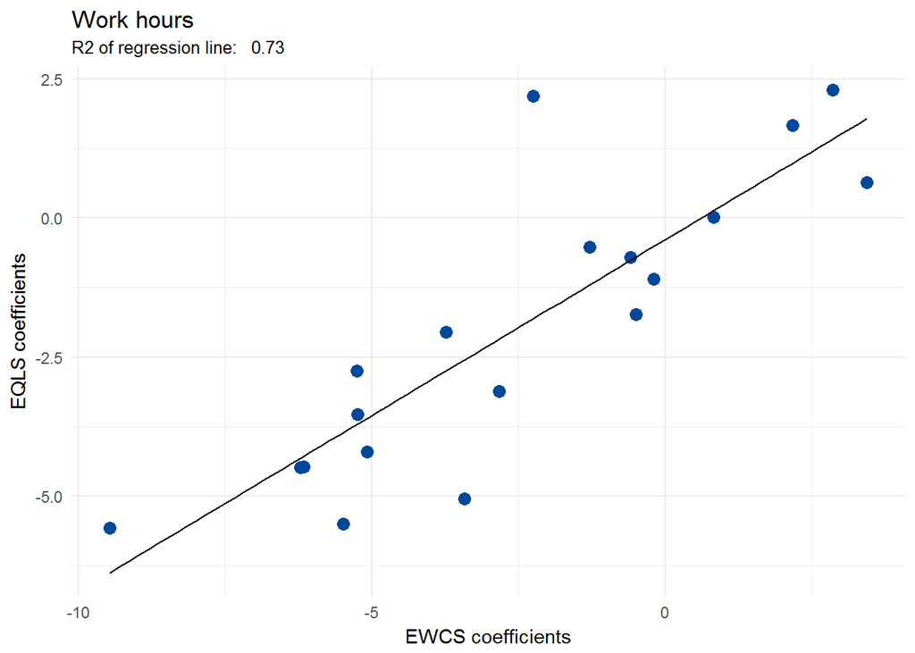

```r
df <- as.data.frame(cbind(glm_EWCS$totalhour[-1,1],glm_EQLS$totalhour[-1,1]))
ggplot(df, aes(x=V1,y=V2)) +
  geom_point(size=3,colour=EF_blue) +
  geom_smooth(method = "lm", se = F, colour="black", size=0.5) +
   labs(title = "Work hours",
       subtitle = paste("R2 of regression line:  ", round(summary(lm(V2 ~ V1 , df))$r.squared,2)),
       x = "EWCS coefficients", y = "EQLS coefficients") +
    theme_minimal()
```

```r
kable(glm_EWCS$totalhour,format="markdown")
```

|  | Estimate | Std. Error | t value | Pr(>\|t\|) |
| --- | --- | --- | --- | --- |
| (Intercept) | 46.7171229 | 0.7471990 | 62.5230027 | 0.0000000 |
| GenderFemale | -5.4875489 | 0.2538464 | -21.6175940 | 0.0000000 |
| empl_stat2employee | -3.4250518 | 0.4158657 | -8.2359569 | 0.0000000 |
| ISCOProfessionals | -5.2432962 | 0.6000460 | -8.7381577 | 0.0000000 |
| ISCOTechnicians and associate professionals | -5.0759745 | 0.6060869 | -8.3749942 | 0.0000000 |
| ISCOClerical support workers | -6.1579280 | 0.6280283 | -9.8051761 | 0.0000000 |
| ISCOService workers | -6.2124721 | 0.6627396 | -9.3739263 | 0.0000000 |
| ISCOSales workers | -5.2565988 | 0.6732976 | -7.8072440 | 0.0000000 |
| ISCOSkilled agricultural, forestry and fishery workers | -2.2480210 | 1.2623683 | -1.7807965 | 0.0750258 |
| ISCOCraft and related trades workers | -3.7340700 | 0.6142325 | -6.0792448 | 0.0000000 |
| ISCOPlant and machine operators and assemblers | -2.8255506 | 0.6562257 | -4.3057605 | 0.0000171 |
| ISCOElementary occupations | -9.4717525 | 0.6999211 | -13.5325993 | 0.0000000 |
| partner_childCouple, no children | 0.8325758 | 0.3038914 | 2.7397146 | 0.0061781 |
| partner_childSingle parent | 2.1751868 | 0.5258057 | 4.1368640 | 0.0000360 |
| partner_childCouple with children | 2.8547092 | 0.3486506 | 8.1878805 | 0.0000000 |
| education_3cat.L | 3.4427551 | 0.5567307 | 6.1838789 | 0.0000000 |
| education_3cat.Q | -1.2791337 | 0.3321436 | -3.8511469 | 0.0001195 |
| migrantBorn in another country | -0.4989249 | 0.4516863 | -1.1045829 | 0.2694106 |
| care_child_grandchild | -0.5821206 | 0.0834627 | -6.9746224 | 0.0000000 |
| care_disabled | -0.1872553 | 0.2412982 | -0.7760329 | 0.4377780 |

```r
kable(glm_EQLS$totalhour,format="markdown")
```

|  | Estimate | Std. Error | t value | Pr(>\|t\|) |
| --- | --- | --- | --- | --- |
| (Intercept) | 51.1865736 | 1.0603651 | 48.2725915 | 0.0000000 |
| GenderFemale | -5.5046745 | 0.3597390 | -15.3018547 | 0.0000000 |
| empl_stat2employee | -5.0430855 | 0.5939255 | -8.4911078 | 0.0000000 |
| ISCOProfessionals | -3.5311952 | 0.8660594 | -4.0773128 | 0.0000468 |
| ISCOTechnicians and associate professionals | -4.1974269 | 0.8135985 | -5.1590885 | 0.0000003 |
| ISCOClerical support workers | -4.4722566 | 0.8738974 | -5.1175994 | 0.0000003 |
| ISCOService workers | -4.4859144 | 0.9151972 | -4.9015825 | 0.0000010 |
| ISCOSales workers | -2.7486906 | 1.0117086 | -2.7168796 | 0.0066296 |
| ISCOSkilled agricultural, forestry and fishery workers | 2.1873747 | 1.4087726 | 1.5526812 | 0.1206095 |
| ISCOCraft and related trades workers | -2.0480030 | 0.9210542 | -2.2235424 | 0.0262567 |
| ISCOPlant and machine operators and assemblers | -3.1130169 | 0.9952973 | -3.1277257 | 0.0017793 |
| ISCOElementary occupations | -5.5695568 | 1.1042350 | -5.0438150 | 0.0000005 |
| partner_childCouple, no children | 0.0174658 | 0.4555509 | 0.0383400 | 0.9694192 |
| partner_childSingle parent | 1.6651229 | 0.8114116 | 2.0521310 | 0.0402474 |
| partner_childCouple with children | 2.2971893 | 0.5511053 | 4.1683306 | 0.0000316 |
| education_3cat.L | 0.6393534 | 0.9076377 | 0.7044148 | 0.4812316 |
| education_3cat.Q | -0.5217885 | 0.5381269 | -0.9696384 | 0.3323084 |
| migrantBorn in another country | -1.7339905 | 0.5896559 | -2.9406821 | 0.0033011 |
| care_child_grandchild | -0.7074402 | 0.1288126 | -5.4920087 | 0.0000000 |
| care_disabled | -1.1034157 | 0.3834542 | -2.8775687 | 0.0040371 |

The categorical variables predict work hours in both surveys in a similar way, despite different levels.

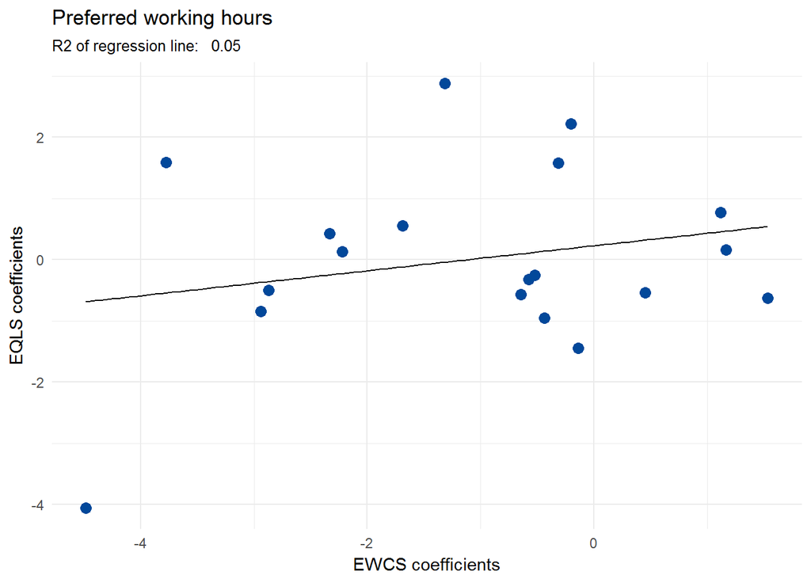

```r
df <- as.data.frame(cbind(glm_EWCS$hours_pref[-1,1],glm_EQLS$hours_pref[-1,1]))
ggplot(df, aes(x=V1,y=V2)) +
  geom_point(size=3,colour=EF_blue) +
  geom_smooth(method = "lm", se = F, colour="black", size=0.5) +
   labs(title = "Preferred working hours",
       subtitle = paste("R2 of regression line:  ", round(summary(lm(V2 ~ V1 , df))$r.squared,2)),
       x = "EWCS coefficients", y = "EQLS coefficients") +
    theme_minimal()
```

```r
kable(glm_EWCS$hours_pref,format="markdown")
```

|  | Estimate | Std. Error | t value | Pr(>\|t\|) |
| --- | --- | --- | --- | --- |
| (Intercept) | 40.4967652 | 0.5635549 | 71.8594823 | 0.0000000 |
| GenderFemale | -4.4815287 | 0.2241407 | -19.9942644 | 0.0000000 |
| empl_stat2employee | -0.6436066 | 0.3391600 | -1.8976488 | 0.0578184 |
| ISCOProfessionals | -2.8686261 | 0.4613943 | -6.2172982 | 0.0000000 |
| ISCOTechnicians and associate professionals | -2.2200253 | 0.4803509 | -4.6216738 | 0.0000039 |
| ISCOClerical support workers | -2.9368121 | 0.4919186 | -5.9701177 | 0.0000000 |
| ISCOService workers | -2.3341975 | 0.5105833 | -4.5716291 | 0.0000050 |
| ISCOSales workers | -1.6882964 | 0.5346986 | -3.1574729 | 0.0016040 |
| ISCOSkilled agricultural, forestry and fishery workers | -1.3170200 | 0.9011561 | -1.4614782 | 0.1439673 |
| ISCOCraft and related trades workers | -0.2007519 | 0.4839342 | -0.4148331 | 0.6782876 |
| ISCOPlant and machine operators and assemblers | -0.3131954 | 0.5046714 | -0.6205928 | 0.5349050 |
| ISCOElementary occupations | -3.7739511 | 0.5237496 | -7.2056396 | 0.0000000 |
| partner_childCouple, no children | -0.4359645 | 0.2593017 | -1.6813020 | 0.0927868 |
| partner_childSingle parent | 1.5370608 | 0.4433772 | 3.4667117 | 0.0005327 |
| partner_childCouple with children | 1.1697850 | 0.3118165 | 3.7515174 | 0.0001784 |
| education_3cat.L | 1.1209366 | 0.4541304 | 2.4683147 | 0.0136190 |
| education_3cat.Q | -0.5721174 | 0.2710679 | -2.1106050 | 0.0348718 |
| migrantBorn in another country | 0.4518644 | 0.3583241 | 1.2610492 | 0.2073689 |
| care_child_grandchild | -0.5220925 | 0.0751743 | -6.9450917 | 0.0000000 |
| care_disabled | -0.1365951 | 0.2051748 | -0.6657497 | 0.5056117 |

```r
kable(glm_EQLS$hours_pref,format="markdown")
```

|  | Estimate | Std. Error | t value | Pr(>\|t\|) |
| --- | --- | --- | --- | --- |
| (Intercept) | 36.8100083 | 0.8422839 | 43.7026143 | 0.0000000 |
| GenderFemale | -4.0579613 | 0.3223761 | -12.5876619 | 0.0000000 |
| empl_stat2employee | -0.5736671 | 0.4864122 | -1.1793845 | 0.2383429 |
| ISCOProfessionals | -0.4976197 | 0.6902968 | -0.7208779 | 0.4710434 |
| ISCOTechnicians and associate professionals | 0.1315425 | 0.6922686 | 0.1900166 | 0.8493096 |
| ISCOClerical support workers | -0.8433356 | 0.7670978 | -1.0993847 | 0.2716926 |
| ISCOService workers | 0.4221199 | 0.7749383 | 0.5447143 | 0.5859924 |
| ISCOSales workers | 0.5563013 | 0.8379565 | 0.6638786 | 0.5068214 |
| ISCOSkilled agricultural, forestry and fishery workers | 2.8773226 | 1.1859885 | 2.4260965 | 0.0153235 |
| ISCOCraft and related trades workers | 2.2144027 | 0.7774006 | 2.8484706 | 0.0044243 |
| ISCOPlant and machine operators and assemblers | 1.5721233 | 0.8360358 | 1.8804496 | 0.0601481 |
| ISCOElementary occupations | 1.5898307 | 0.7836277 | 2.0288086 | 0.0425700 |
| partner_childCouple, no children | -0.9561456 | 0.4152455 | -2.3026031 | 0.0213725 |
| partner_childSingle parent | -0.6265356 | 0.7569022 | -0.8277630 | 0.4078736 |
| partner_childCouple with children | 0.1618599 | 0.4350559 | 0.3720439 | 0.7098877 |
| education_3cat.L | 0.7713022 | 0.6931827 | 1.1126969 | 0.2659319 |
| education_3cat.Q | -0.3255574 | 0.4374627 | -0.7441946 | 0.4568197 |
| migrantBorn in another country | -0.5441300 | 0.5480887 | -0.9927772 | 0.3209023 |
| care_child_grandchild | -0.2606201 | 0.1065383 | -2.4462583 | 0.0144944 |
| care_disabled | -1.4483848 | 0.3803388 | -3.8081433 | 0.0001429 |

Strong differences in preferred working hours. Mostly situated around occupations, but also other variables (household size, migrant)

```r
df <- as.data.frame(cbind(glm_EWCS$partner_hour[-1,1],glm_EQLS$partner_hour[-1,1]))
```

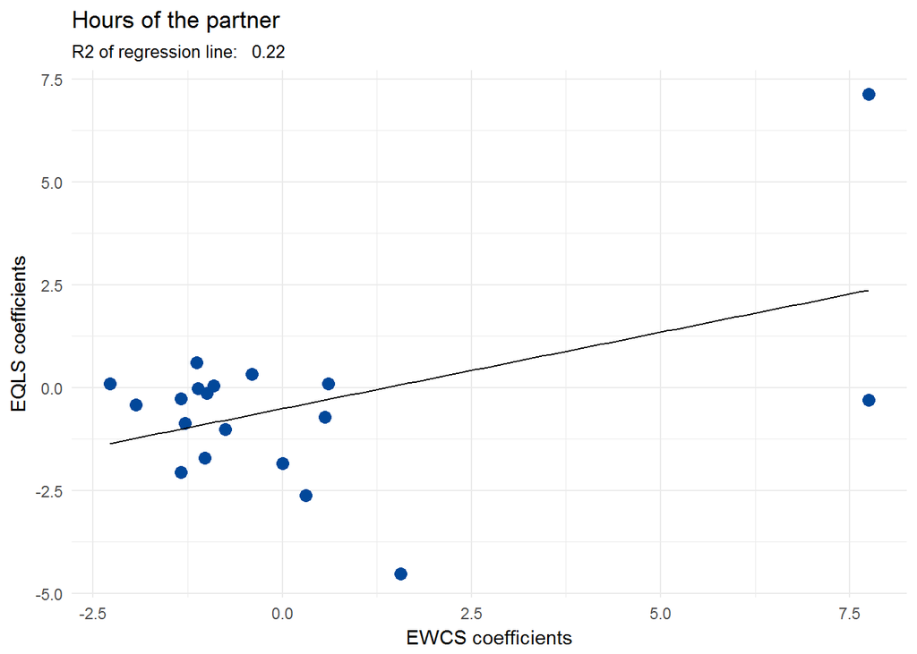

```r
ggplot(df, aes(x=V1,y=V2)) +
  geom_point(size=3,colour=EF_blue) +
  geom_smooth(method = "lm", se = F, colour="black", size=0.5) +
   labs(title = "Hours of the partner",
       subtitle = paste("R2 of regression line:  ", round(summary(lm(V2 ~ V1 , df))$r.squared,2)),
       x = "EWCS coefficients", y = "EQLS coefficients") +
    theme_minimal()
```

```r
kable(glm_EWCS$partner_hour,format="markdown")
```

|  | Estimate | Std. Error | t value | Pr(>\|t\|) |
| --- | --- | --- | --- | --- |
| (Intercept) | 36.4884085 | 0.8731146 | 41.7910884 | 0.0000000 |
| GenderFemale | 7.7525439 | 0.3439337 | 22.5408069 | 0.0000000 |
| empl_stat2employee | -1.3407066 | 0.5124559 | -2.6162381 | 0.0089301 |
| ISCOProfessionals | -1.0015304 | 0.7699221 | -1.3008205 | 0.1934087 |
| ISCOTechnicians and associate professionals | -1.2850055 | 0.8093515 | -1.5876978 | 0.1124484 |
| ISCOClerical support workers | -0.9051447 | 0.7998879 | -1.1315894 | 0.2578875 |
| ISCOService workers | -1.1132508 | 0.8554949 | -1.3012945 | 0.1932465 |
| ISCOSales workers | -1.1321394 | 0.8681960 | -1.3040136 | 0.1923179 |
| ISCOSkilled agricultural, forestry and fishery workers | 0.6102948 | 1.4771045 | 0.4131697 | 0.6795085 |
| ISCOCraft and related trades workers | -2.2822524 | 0.8620114 | -2.6475895 | 0.0081445 |
| ISCOPlant and machine operators and assemblers | -1.0249438 | 0.9182042 | -1.1162483 | 0.2643953 |
| ISCOElementary occupations | -1.9379698 | 0.8705645 | -2.2261072 | 0.0260728 |
| partner_childCouple with children | 0.3135030 | 0.4351230 | 0.7204929 | 0.4712715 |
| education_3cat.L | 1.5657832 | 0.8611337 | 1.8182812 | 0.0691098 |
| education_3cat.Q | -0.7529407 | 0.5009138 | -1.5031342 | 0.1328980 |
| migrantBorn in another country | 0.5616024 | 0.5785821 | 0.9706529 | 0.3317907 |
| care_child_grandchild | -0.4051020 | 0.1278062 | -3.1696571 | 0.0015398 |
| care_disabled | 0.0052153 | 0.3331979 | 0.0156523 | 0.9875127 |

```r
kable(glm_EQLS$partner_hour,format="markdown")
```

|  | Estimate | Std. Error | t value | Pr(>\|t\|) |
| --- | --- | --- | --- | --- |
| (Intercept) | 40.2026902 | 4.2991861 | 9.3512328 | 0.0000000 |
| GenderFemale | 7.1362031 | 0.5037897 | 14.1650425 | 0.0000000 |
| empl_stat2employee | -2.0619347 | 0.6760045 | -3.0501790 | 0.0023106 |
| ISCOProfessionals | -0.1436037 | 1.0553567 | -0.1360712 | 0.8917757 |
| ISCOTechnicians and associate professionals | -0.8588547 | 1.0735381 | -0.8000226 | 0.4237724 |
| ISCOClerical support workers | 0.0521926 | 0.9778927 | 0.0533725 | 0.9574393 |
| ISCOService workers | -0.0146073 | 1.1264473 | -0.0129676 | 0.9896547 |
| ISCOSales workers | 0.6095168 | 1.2319866 | 0.4947430 | 0.6208242 |
| ISCOSkilled agricultural, forestry and fishery workers | 0.0894375 | 1.9229624 | 0.0465103 | 0.9629072 |
| ISCOCraft and related trades workers | 0.0956478 | 1.1841659 | 0.0807723 | 0.9356294 |
| ISCOPlant and machine operators and assemblers | -1.7164485 | 1.7376929 | -0.9877744 | 0.3233570 |
| ISCOElementary occupations | -0.4103187 | 1.3192020 | -0.3110355 | 0.7557991 |
| partner_childCouple, no children | -2.6187348 | 4.0646575 | -0.6442695 | 0.5194587 |
| partner_childSingle parent | -4.5248210 | 4.1381232 | -1.0934476 | 0.2743008 |
| partner_childCouple with children | -1.0147586 | 4.1131297 | -0.2467120 | 0.8051510 |
| education_3cat.L | -0.7200443 | 1.2695304 | -0.5671737 | 0.5706461 |
| education_3cat.Q | 0.3309080 | 0.7267493 | 0.4553263 | 0.6489134 |
| migrantBorn in another country | -1.8441745 | 0.8463965 | -2.1788542 | 0.0294339 |
| care_child_grandchild | -0.2944097 | 0.1752912 | -1.6795467 | 0.0931682 |
| care_disabled | -0.2636144 | 0.5154747 | -0.5114013 | 0.6091145 |

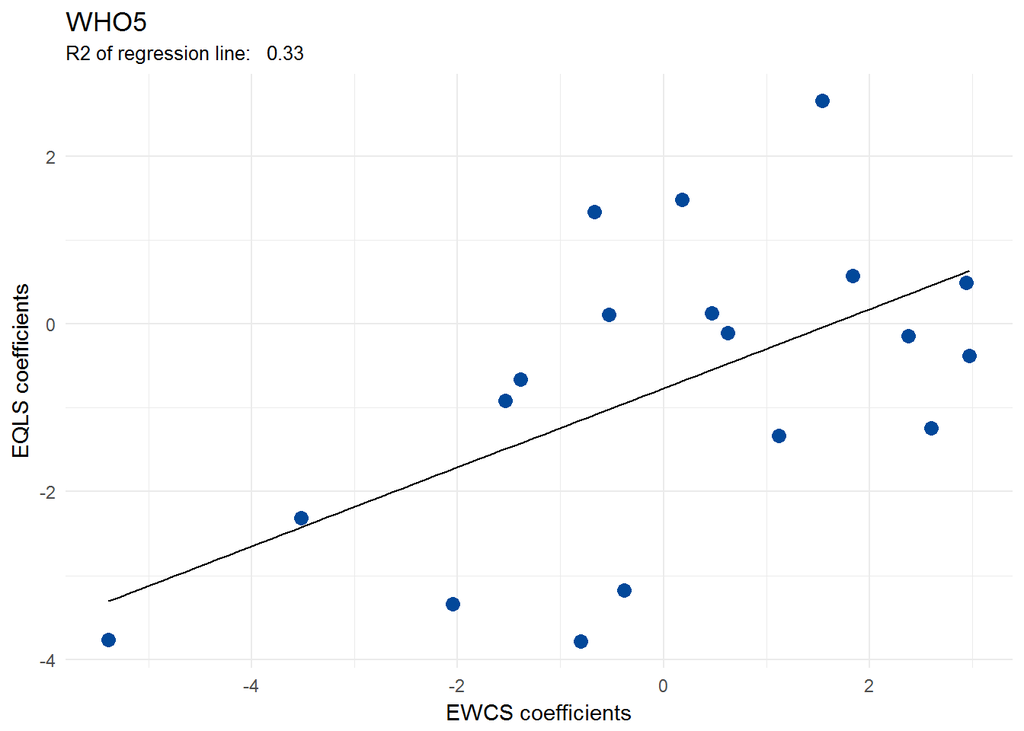

```r
df <- as.data.frame(cbind(glm_EWCS$who5[-1,1],glm_EQLS$who5[-1,1]))
ggplot(df, aes(x=V1,y=V2)) +
  geom_point(size=3,colour=EF_blue) +
  geom_smooth(method = "lm", se = F, colour="black", size=0.5) +
   labs(title = "WHO5",
       subtitle = paste("R2 of regression line:  ", round(summary(lm(V2 ~ V1 , df))$r.squared,2)),
       x = "EWCS coefficients", y = "EQLS coefficients") +
    theme_minimal()
```

```r
kable(glm_EWCS$who5,format="markdown")
```

|  | Estimate | Std. Error | t value | Pr(>\|t\|) |
| --- | --- | --- | --- | --- |
| (Intercept) | 68.0750081 | 1.0720720 | 63.4985421 | 0.0000000 |
| GenderFemale | -2.0476437 | 0.4290367 | -4.7726544 | 0.0000019 |
| empl_stat2employee | -0.5286144 | 0.6039173 | -0.8753093 | 0.3814611 |
| ISCOProfessionals | 2.6007812 | 0.8856113 | 2.9367073 | 0.0033372 |
| ISCOTechnicians and associate professionals | 2.9435040 | 0.9660630 | 3.0469069 | 0.0023280 |
| ISCOClerical support workers | 2.3778008 | 1.0500784 | 2.2644031 | 0.0236056 |
| ISCOService workers | 1.8359295 | 1.0526787 | 1.7440550 | 0.0812306 |
| ISCOSales workers | 0.6251045 | 1.0164036 | 0.6150160 | 0.5385811 |
| ISCOSkilled agricultural, forestry and fishery workers | 2.9746783 | 1.3122095 | 2.2669233 | 0.0234510 |
| ISCOCraft and related trades workers | 1.1214884 | 0.9844913 | 1.1391552 | 0.2547105 |
| ISCOPlant and machine operators and assemblers | -0.3826902 | 1.0463755 | -0.3657293 | 0.7145875 |
| ISCOElementary occupations | -0.8023549 | 1.0637772 | -0.7542509 | 0.4507455 |
| partner_childCouple, no children | -0.6701606 | 0.5596920 | -1.1973739 | 0.2312358 |
| partner_childSingle parent | -5.3902989 | 0.9466042 | -5.6943535 | 0.0000000 |
| partner_childCouple with children | -1.5382722 | 0.6877367 | -2.2367167 | 0.0253628 |
| education_3cat.L | 1.5395433 | 0.8365037 | 1.8404501 | 0.0657804 |
| education_3cat.Q | -1.3845938 | 0.5183481 | -2.6711662 | 0.0075911 |
| migrantBorn in another country | 0.1805914 | 0.8394224 | 0.2151377 | 0.8296715 |
| care_child_grandchild | 0.4720521 | 0.1750409 | 2.6968096 | 0.0070317 |
| care_disabled | -3.5173568 | 0.4774224 | -7.3673900 | 0.0000000 |

```r
kable(glm_EQLS$who5,format="markdown")
```

|  | Estimate | Std. Error | t value | Pr(>\|t\|) |
| --- | --- | --- | --- | --- |
| (Intercept) | 67.9715085 | 1.3267544 | 51.2314177 | 0.0000000 |
| GenderFemale | -3.3408444 | 0.6044758 | -5.5268457 | 0.0000000 |
| empl_stat2employee | 0.1063538 | 0.7373525 | 0.1442373 | 0.8853232 |
| ISCOProfessionals | -1.2462001 | 1.0793889 | -1.1545423 | 0.2483739 |
| ISCOTechnicians and associate professionals | 0.4919378 | 1.1248213 | 0.4373475 | 0.6618922 |
| ISCOClerical support workers | -0.1399196 | 1.1787903 | -0.1186976 | 0.9055232 |
| ISCOService workers | 0.5738520 | 1.2216474 | 0.4697362 | 0.6385792 |
| ISCOSales workers | -0.1062994 | 1.2796790 | -0.0830672 | 0.9338039 |
| ISCOSkilled agricultural, forestry and fishery workers | -0.3822454 | 1.9418221 | -0.1968488 | 0.8439598 |
| ISCOCraft and related trades workers | -1.3288280 | 1.2097035 | -1.0984741 | 0.2720895 |
| ISCOPlant and machine operators and assemblers | -3.1763685 | 1.5406860 | -2.0616586 | 0.0393300 |
| ISCOElementary occupations | -3.7812919 | 1.4879660 | -2.5412489 | 0.0110979 |
| partner_childCouple, no children | 1.3337378 | 0.7223686 | 1.8463396 | 0.0649457 |
| partner_childSingle parent | -3.7688794 | 1.4098548 | -2.6732395 | 0.0075547 |
| partner_childCouple with children | -0.9193014 | 0.9597064 | -0.9578985 | 0.3381945 |
| education_3cat.L | 2.6592629 | 1.2899504 | 2.0615234 | 0.0393429 |
| education_3cat.Q | -0.6588724 | 0.7443648 | -0.8851472 | 0.3761513 |
| migrantBorn in another country | 1.4853481 | 0.9644280 | 1.5401338 | 0.1236378 |
| care_child_grandchild | 0.1252198 | 0.2165591 | 0.5782244 | 0.5631579 |
| care_disabled | -2.3113320 | 0.6143732 | -3.7620974 | 0.0001719 |

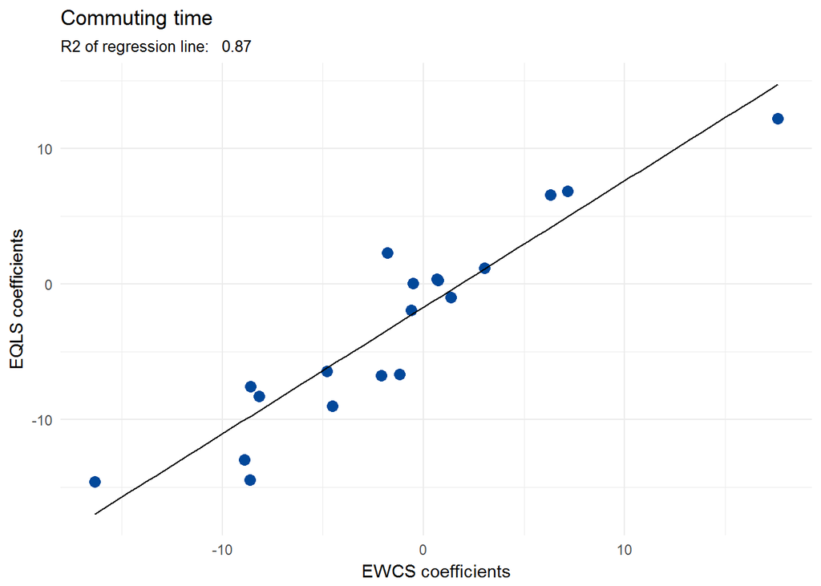

```r
df <- as.data.frame(cbind(glm_EWCS$commute_time[-1,1],glm_EQLS$commute_time[-1,1]))
ggplot(df, aes(x=V1,y=V2)) +
  geom_point(size=3,colour=EF_blue) +
  geom_smooth(method = "lm", se = F, colour="black", size=0.5) +
   labs(title = "Commuting time",
       subtitle = paste("R2 of regression line:  ", round(summary(lm(V2 ~ V1 , df))$r.squared,2)),
       x = "EWCS coefficients", y = "EQLS coefficients") +
    theme_minimal()
```

```r
kable(glm_EWCS$commute_time,format="markdown")
```

|  | Estimate | Std. Error | t value | Pr(>\|t\|) |
| --- | --- | --- | --- | --- |
| (Intercept) | 29.0724792 | 2.1111087 | 13.7711902 | 0.0000000 |
| GenderFemale | -4.7901209 | 0.7080980 | -6.7647713 | 0.0000000 |
| empl_stat2employee | 17.6087851 | 1.0513892 | 16.7481131 | 0.0000000 |
| ISCOProfessionals | -0.6060131 | 1.8595232 | -0.3258970 | 0.7445203 |
| ISCOTechnicians and associate professionals | -1.1945166 | 1.8296201 | -0.6528768 | 0.5138753 |
| ISCOClerical support workers | -2.0993733 | 1.9712307 | -1.0650064 | 0.2869409 |
| ISCOService workers | -8.5871027 | 1.9102234 | -4.4953395 | 0.0000072 |
| ISCOSales workers | -8.1841998 | 1.8765315 | -4.3613442 | 0.0000133 |
| ISCOSkilled agricultural, forestry and fishery workers | -16.3473222 | 2.0678448 | -7.9054879 | 0.0000000 |
| ISCOCraft and related trades workers | -4.5387873 | 1.9081820 | -2.3785924 | 0.0174282 |
| ISCOPlant and machine operators and assemblers | -8.6378910 | 2.0817536 | -4.1493341 | 0.0000341 |
| ISCOElementary occupations | -8.9124668 | 1.9291624 | -4.6198634 | 0.0000040 |
| partner_childCouple, no children | 1.3614818 | 0.9420198 | 1.4452794 | 0.1484621 |
| partner_childSingle parent | 3.0430545 | 1.4724619 | 2.0666440 | 0.0388355 |
| partner_childCouple with children | 0.7191436 | 1.1703895 | 0.6144481 | 0.5389562 |
| education_3cat.L | 6.3175342 | 1.2277157 | 5.1457632 | 0.0000003 |
| education_3cat.Q | 0.6702292 | 0.7967225 | 0.8412329 | 0.4002705 |
| migrantBorn in another country | 7.1494555 | 1.4709419 | 4.8604610 | 0.0000012 |
| care_child_grandchild | -0.5177486 | 0.2677054 | -1.9340237 | 0.0531846 |
| care_disabled | -1.7844081 | 0.7724947 | -2.3099293 | 0.0209456 |

```r
kable(glm_EQLS$commute_time,format="markdown")
```

|  | Estimate | Std. Error | t value | Pr(>\|t\|) |
| --- | --- | --- | --- | --- |
| (Intercept) | 35.3450434 | 2.8173712 | 12.5453981 | 0.0000000 |
| GenderFemale | -6.4368676 | 1.1729235 | -5.4878834 | 0.0000000 |
| empl_stat2employee | 12.2060942 | 1.4443533 | 8.4509062 | 0.0000000 |
| ISCOProfessionals | -1.9509362 | 2.7890067 | -0.6995093 | 0.4842905 |
| ISCOTechnicians and associate professionals | -6.6698319 | 2.6496574 | -2.5172431 | 0.0118818 |
| ISCOClerical support workers | -6.7730576 | 2.5641122 | -2.6414826 | 0.0082992 |
| ISCOService workers | -7.5820368 | 2.7593920 | -2.7477201 | 0.0060386 |
| ISCOSales workers | -8.2763768 | 2.7703082 | -2.9875292 | 0.0028363 |
| ISCOSkilled agricultural, forestry and fishery workers | -14.5807218 | 2.9280388 | -4.9796888 | 0.0000007 |
| ISCOCraft and related trades workers | -9.0189668 | 2.6238409 | -3.4373146 | 0.0005959 |
| ISCOPlant and machine operators and assemblers | -14.4524444 | 2.8888839 | -5.0027779 | 0.0000006 |
| ISCOElementary occupations | -12.9742560 | 2.7701596 | -4.6835770 | 0.0000030 |
| partner_childCouple, no children | -1.0085551 | 1.3974077 | -0.7217328 | 0.4705176 |
| partner_childSingle parent | 1.1779905 | 2.8387260 | 0.4149715 | 0.6781938 |
| partner_childCouple with children | 0.2665880 | 1.7702704 | 0.1505917 | 0.8803084 |
| education_3cat.L | 6.5630407 | 1.9293376 | 3.4017067 | 0.0006788 |
| education_3cat.Q | 0.3836248 | 1.2420128 | 0.3088734 | 0.7574402 |
| migrantBorn in another country | 6.8667232 | 2.9313802 | 2.3424881 | 0.0192237 |
| care_child_grandchild | 0.0454844 | 0.4129405 | 0.1101477 | 0.9123000 |
| care_disabled | 2.3069261 | 1.2261437 | 1.8814484 | 0.0600121 |

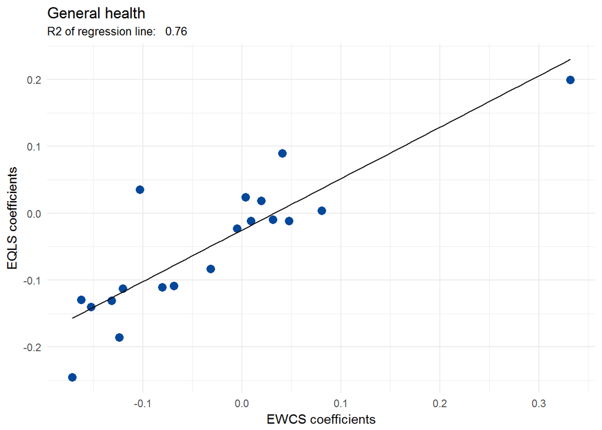

```r
df <- as.data.frame(cbind(glm_EWCS$gen_health[-1,1],glm_EQLS$gen_health[-1,1]))
ggplot(df, aes(x=V1,y=V2)) +
  geom_point(size=3,colour=EF_blue) +
  geom_smooth(method = "lm", se = F, colour="black", size=0.5) +
   labs(title = "General health",
       subtitle = paste("R2 of regression line:  ", round(summary(lm(V2 ~ V1 , df))$r.squared,2)),
       x = "EWCS coefficients", y = "EQLS coefficients") +
    theme_minimal()
```

```r
kable(glm_EWCS$gen_health,format="markdown")
```

|  | Estimate | Std. Error | t value | Pr(>\|t\|) |
| --- | --- | --- | --- | --- |
| (Intercept) | 3.9622033 | 0.0409227 | 96.8217090 | 0.0000000 |
| GenderFemale | -0.0316410 | 0.0155787 | -2.0310408 | 0.0423206 |
| empl_stat2employee | 0.0805165 | 0.0207884 | 3.8731405 | 0.0001093 |
| ISCOProfessionals | 0.0311294 | 0.0371595 | 0.8377228 | 0.4022393 |
| ISCOTechnicians and associate professionals | 0.0477013 | 0.0354973 | 1.3438014 | 0.1790931 |
| ISCOClerical support workers | 0.0092372 | 0.0392857 | 0.2351286 | 0.8141216 |
| ISCOService workers | -0.0049698 | 0.0377129 | -0.1317790 | 0.8951661 |
| ISCOSales workers | 0.0193744 | 0.0384485 | 0.5039058 | 0.6143569 |
| ISCOSkilled agricultural, forestry and fishery workers | -0.1622321 | 0.0509344 | -3.1851181 | 0.0014587 |
| ISCOCraft and related trades workers | -0.0806211 | 0.0393379 | -2.0494489 | 0.0404870 |
| ISCOPlant and machine operators and assemblers | -0.1240964 | 0.0397647 | -3.1207658 | 0.0018174 |
| ISCOElementary occupations | -0.1525341 | 0.0391011 | -3.9010211 | 0.0000975 |
| partner_childCouple, no children | -0.1202850 | 0.0207826 | -5.7877852 | 0.0000000 |
| partner_childSingle parent | -0.1716103 | 0.0326836 | -5.2506480 | 0.0000002 |
| partner_childCouple with children | -0.0687624 | 0.0242845 | -2.8315405 | 0.0046569 |
| education_3cat.L | 0.3318608 | 0.0313742 | 10.5775065 | 0.0000000 |
| education_3cat.Q | -0.1031167 | 0.0187140 | -5.5101400 | 0.0000000 |
| migrantBorn in another country | 0.0409560 | 0.0257975 | 1.5875943 | 0.1124616 |
| care_child_grandchild | 0.0035924 | 0.0056818 | 0.6322579 | 0.5272565 |
| care_disabled | -0.1316049 | 0.0158583 | -8.2987907 | 0.0000000 |

```r
kable(glm_EQLS$gen_health,format="markdown")
```

|  | Estimate | Std. Error | t value | Pr(>\|t\|) |
| --- | --- | --- | --- | --- |
| (Intercept) | 4.1681071 | 0.0619535 | 67.2780054 | 0.0000000 |
| GenderFemale | -0.0834904 | 0.0247729 | -3.3702340 | 0.0007610 |
| empl_stat2employee | 0.0041321 | 0.0315814 | 0.1308386 | 0.8959122 |
| ISCOProfessionals | -0.0094970 | 0.0467289 | -0.2032369 | 0.8389642 |
| ISCOTechnicians and associate professionals | -0.0115010 | 0.0491005 | -0.2342338 | 0.8148202 |
| ISCOClerical support workers | -0.0114050 | 0.0508848 | -0.2241329 | 0.8226698 |
| ISCOService workers | -0.0227852 | 0.0517505 | -0.4402897 | 0.6597604 |
| ISCOSales workers | 0.0186821 | 0.0534590 | 0.3494656 | 0.7267654 |
| ISCOSkilled agricultural, forestry and fishery workers | -0.1295737 | 0.0797136 | -1.6254909 | 0.1041676 |
| ISCOCraft and related trades workers | -0.1109616 | 0.0544286 | -2.0386614 | 0.0415751 |
| ISCOPlant and machine operators and assemblers | -0.1861623 | 0.0734663 | -2.5339812 | 0.0113301 |
| ISCOElementary occupations | -0.1400304 | 0.0609973 | -2.2956804 | 0.0217658 |
| partner_childCouple, no children | -0.1127680 | 0.0277648 | -4.0615398 | 0.0000501 |
| partner_childSingle parent | -0.2452363 | 0.0761891 | -3.2187854 | 0.0013017 |
| partner_childCouple with children | -0.1084365 | 0.0382366 | -2.8359353 | 0.0046011 |
| education_3cat.L | 0.1992469 | 0.0531831 | 3.7464338 | 0.0001829 |
| education_3cat.Q | 0.0355026 | 0.0310346 | 1.1439651 | 0.2527333 |
| migrantBorn in another country | 0.0895487 | 0.0366092 | 2.4460726 | 0.0145017 |
| care_child_grandchild | 0.0239589 | 0.0094428 | 2.5372524 | 0.0112250 |
| care_disabled | -0.1307472 | 0.0248904 | -5.2529142 | 0.0000002 |

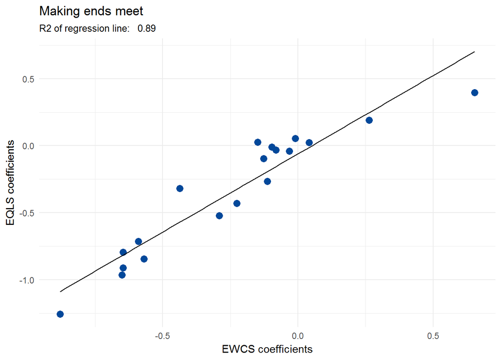

```r
df <- as.data.frame(cbind(glm_EWCS$make_ends_meet[-1,1],glm_EQLS$make_ends_meet[-1,1]))
ggplot(df, aes(x=V1,y=V2)) +
  geom_point(size=3,colour=EF_blue) +
  geom_smooth(method = "lm", se = F, colour="black", size=0.5) +
   labs(title = "Making ends meet",
       subtitle = paste("R2 of regression line:  ", round(summary(lm(V2 ~ V1 , df))$r.squared,2)),
       x = "EWCS coefficients", y = "EQLS coefficients") +
    theme_minimal()
```

```r
kable(glm_EWCS$make_ends_meet,format="markdown")
```

|  | Estimate | Std. Error | t value | Pr(>\|t\|) |
| --- | --- | --- | --- | --- |
| (Intercept) | 4.2896878 | 0.0587731 | 72.9872058 | 0.0000000 |
| GenderFemale | -0.0813876 | 0.0223909 | -3.6348466 | 0.0002818 |
| empl_stat2employee | -0.0093795 | 0.0340835 | -0.2751908 | 0.7831847 |
| ISCOProfessionals | -0.1132869 | 0.0516657 | -2.1926917 | 0.0283902 |
| ISCOTechnicians and associate professionals | -0.2260620 | 0.0521504 | -4.3348125 | 0.0000150 |
| ISCOClerical support workers | -0.2908319 | 0.0556419 | -5.2268480 | 0.0000002 |
| ISCOService workers | -0.5894619 | 0.0568121 | -10.3756395 | 0.0000000 |
| ISCOSales workers | -0.6458003 | 0.0637664 | -10.1275970 | 0.0000000 |
| ISCOSkilled agricultural, forestry and fishery workers | -0.6504133 | 0.0754087 | -8.6251764 | 0.0000000 |
| ISCOCraft and related trades workers | -0.5697652 | 0.0583129 | -9.7708321 | 0.0000000 |
| ISCOPlant and machine operators and assemblers | -0.6465631 | 0.0604261 | -10.7000632 | 0.0000000 |
| ISCOElementary occupations | -0.8800033 | 0.0606557 | -14.5081669 | 0.0000000 |
| partner_childCouple, no children | 0.2634922 | 0.0307935 | 8.5567388 | 0.0000000 |
| partner_childSingle parent | -0.4375594 | 0.0496653 | -8.8101649 | 0.0000000 |
| partner_childCouple with children | 0.0412227 | 0.0360579 | 1.1432357 | 0.2530130 |
| education_3cat.L | 0.6535803 | 0.0451044 | 14.4904051 | 0.0000000 |
| education_3cat.Q | -0.1493127 | 0.0275718 | -5.4154229 | 0.0000001 |
| migrantBorn in another country | -0.0966811 | 0.0477538 | -2.0245742 | 0.0429811 |
| care_child_grandchild | -0.0314416 | 0.0090850 | -3.4608360 | 0.0005445 |
| care_disabled | -0.1263887 | 0.0246851 | -5.1200450 | 0.0000003 |

```r
kable(glm_EQLS$make_ends_meet,format="markdown")
```

|  | Estimate | Std. Error | t value | Pr(>\|t\|) |
| --- | --- | --- | --- | --- |
| (Intercept) | 4.6054365 | 0.0866431 | 53.1541242 | 0.0000000 |
| GenderFemale | -0.0315910 | 0.0344819 | -0.9161629 | 0.3596583 |
| empl_stat2employee | 0.0551686 | 0.0494040 | 1.1166843 | 0.2642227 |
| ISCOProfessionals | -0.2651525 | 0.0656583 | -4.0383702 | 0.0000552 |
| ISCOTechnicians and associate professionals | -0.4302705 | 0.0746937 | -5.7604679 | 0.0000000 |
| ISCOClerical support workers | -0.5226835 | 0.0795454 | -6.5708850 | 0.0000000 |
| ISCOService workers | -0.7133755 | 0.0749891 | -9.5130567 | 0.0000000 |
| ISCOSales workers | -0.9115267 | 0.0765063 | -11.9143968 | 0.0000000 |
| ISCOSkilled agricultural, forestry and fishery workers | -0.9632410 | 0.1100142 | -8.7556070 | 0.0000000 |
| ISCOCraft and related trades workers | -0.8444537 | 0.0788053 | -10.7156898 | 0.0000000 |
| ISCOPlant and machine operators and assemblers | -0.7947977 | 0.1066920 | -7.4494563 | 0.0000000 |
| ISCOElementary occupations | -1.2555711 | 0.0910575 | -13.7887719 | 0.0000000 |
| partner_childCouple, no children | 0.1893486 | 0.0453553 | 4.1747853 | 0.0000307 |
| partner_childSingle parent | -0.3184117 | 0.0899293 | -3.5406908 | 0.0004054 |
| partner_childCouple with children | 0.0238681 | 0.0570071 | 0.4186860 | 0.6754769 |
| education_3cat.L | 0.3971348 | 0.1067636 | 3.7197592 | 0.0002032 |
| education_3cat.Q | 0.0258607 | 0.0611968 | 0.4225823 | 0.6726316 |
| migrantBorn in another country | -0.0096066 | 0.0585341 | -0.1641200 | 0.8696482 |
| care_child_grandchild | -0.0400370 | 0.0130328 | -3.0720037 | 0.0021462 |
| care_disabled | -0.0960733 | 0.0391855 | -2.4517522 | 0.0142754 |

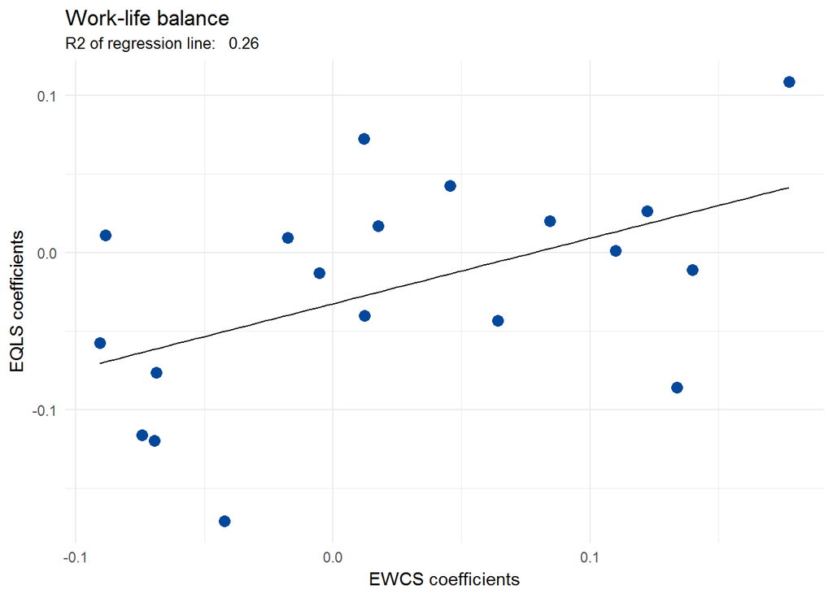

```r
df <- as.data.frame(cbind(glm_EWCS$WorkLB[-1,1],glm_EQLS$WorkLB[-1,1]))
ggplot(df, aes(x=V1,y=V2)) +
  geom_point(size=3,colour=EF_blue) +
  geom_smooth(method = "lm", se = F, colour="black", size=0.5) +
   labs(title = "Work-life balance",
       subtitle = paste("R2 of regression line:  ", round(summary(lm(V2 ~ V1 , df))$r.squared,2)),
       x = "EWCS coefficients", y = "EQLS coefficients") +
    theme_minimal()
```

```r
kable(glm_EWCS$WorkLB,format="markdown")
```

|  | Estimate | Std. Error | t value | Pr(>\|t\|) |
| --- | --- | --- | --- | --- |
| (Intercept) | 2.9895516 | 0.0389914 | 76.6721312 | 0.0000000 |
| GenderFemale | 0.0845429 | 0.0149423 | 5.6579518 | 0.0000000 |
| empl_stat2employee | 0.0456940 | 0.0227300 | 2.0102974 | 0.0444705 |
| ISCOProfessionals | 0.1098984 | 0.0359626 | 3.0559106 | 0.0022594 |
| ISCOTechnicians and associate professionals | 0.1223338 | 0.0388743 | 3.1469107 | 0.0016629 |
| ISCOClerical support workers | 0.1775814 | 0.0397751 | 4.4646361 | 0.0000083 |
| ISCOService workers | -0.0176162 | 0.0383133 | -0.4597924 | 0.6456916 |
| ISCOSales workers | -0.0421704 | 0.0397602 | -1.0606179 | 0.2889312 |
| ISCOSkilled agricultural, forestry and fishery workers | 0.1338029 | 0.0528385 | 2.5323011 | 0.0113717 |
| ISCOCraft and related trades workers | 0.0641472 | 0.0362141 | 1.7713330 | 0.0765857 |
| ISCOPlant and machine operators and assemblers | -0.0907612 | 0.0407990 | -2.2245951 | 0.0261671 |
| ISCOElementary occupations | 0.1398214 | 0.0405486 | 3.4482421 | 0.0005704 |
| partner_childCouple, no children | 0.0122917 | 0.0190063 | 0.6467152 | 0.5178555 |
| partner_childSingle parent | -0.0742855 | 0.0310411 | -2.3931350 | 0.0167535 |
| partner_childCouple with children | -0.0693554 | 0.0236100 | -2.9375479 | 0.0033281 |
| education_3cat.L | 0.0120465 | 0.0271193 | 0.4442045 | 0.6569201 |
| education_3cat.Q | 0.0176151 | 0.0171562 | 1.0267492 | 0.3046041 |
| migrantBorn in another country | -0.0687969 | 0.0258778 | -2.6585323 | 0.0078812 |
| care_child_grandchild | -0.0053804 | 0.0058065 | -0.9266123 | 0.3541869 |
| care_disabled | -0.0885432 | 0.0158221 | -5.5961812 | 0.0000000 |

```r
kable(glm_EQLS$WorkLB,format="markdown")
```

|  | Estimate | Std. Error | t value | Pr(>\|t\|) |
| --- | --- | --- | --- | --- |
| (Intercept) | 3.0362323 | 0.0582708 | 52.1055257 | 0.0000000 |
| GenderFemale | 0.0201141 | 0.0233729 | 0.8605721 | 0.3895456 |
| empl_stat2employee | 0.0425033 | 0.0323861 | 1.3123940 | 0.1894921 |
| ISCOProfessionals | 0.0013836 | 0.0517790 | 0.0267220 | 0.9786833 |
| ISCOTechnicians and associate professionals | 0.0265318 | 0.0541231 | 0.4902117 | 0.6240216 |
| ISCOClerical support workers | 0.1085963 | 0.0533252 | 2.0364904 | 0.0417927 |
| ISCOService workers | 0.0095530 | 0.0526207 | 0.1815446 | 0.8559530 |
| ISCOSales workers | -0.1706984 | 0.0577354 | -2.9565627 | 0.0031362 |
| ISCOSkilled agricultural, forestry and fishery workers | -0.0859235 | 0.0775392 | -1.1081294 | 0.2678987 |
| ISCOCraft and related trades workers | -0.0434190 | 0.0563159 | -0.7709894 | 0.4407766 |
| ISCOPlant and machine operators and assemblers | -0.0572843 | 0.0689365 | -0.8309716 | 0.4060588 |
| ISCOElementary occupations | -0.0110954 | 0.0642703 | -0.1726371 | 0.8629489 |
| partner_childCouple, no children | -0.0399894 | 0.0300100 | -1.3325376 | 0.1827893 |
| partner_childSingle parent | -0.1160959 | 0.0666922 | -1.7407724 | 0.0818306 |
| partner_childCouple with children | -0.1198427 | 0.0372026 | -3.2213535 | 0.0012901 |
| education_3cat.L | 0.0723605 | 0.0443979 | 1.6298171 | 0.1032498 |
| education_3cat.Q | 0.0170623 | 0.0291396 | 0.5855374 | 0.5582325 |
| migrantBorn in another country | -0.0762615 | 0.0348187 | -2.1902435 | 0.0285867 |
| care_child_grandchild | -0.0130999 | 0.0086985 | -1.5059944 | 0.1321786 |
| care_disabled | 0.0109787 | 0.0236691 | 0.4638402 | 0.6427974 |

Seems quite different, but coefficients are very small so it is hard to say

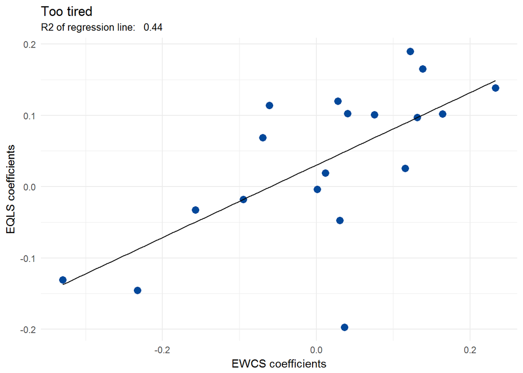

```r
df <- as.data.frame(cbind(glm_EWCS$too_tired[-1,1],glm_EQLS$too_tired[-1,1]))
ggplot(df, aes(x=V1,y=V2)) +
  geom_point(size=3,colour=EF_blue) +
  geom_smooth(method = "lm", se = F, colour="black", size=0.5) +
   labs(title = "Too tired",
       subtitle = paste("R2 of regression line:  ", round(summary(lm(V2 ~ V1 , df))$r.squared,2)),
       x = "EWCS coefficients", y = "EQLS coefficients") +
    theme_minimal()
```

```r
kable(glm_EWCS$too_tired,format="markdown")
```

|  | Estimate | Std. Error | t value | Pr(>\|t\|) |
| --- | --- | --- | --- | --- |
| (Intercept) | 1.6343728 | 0.0616573 | 26.5073897 | 0.0000000 |
| GenderFemale | 0.1641522 | 0.0241192 | 6.8058690 | 0.0000000 |
| empl_stat2employee | -0.0949769 | 0.0324840 | -2.9238085 | 0.0034783 |
| ISCOProfessionals | -0.1571621 | 0.0559349 | -2.8097318 | 0.0049837 |
| ISCOTechnicians and associate professionals | -0.2326829 | 0.0545825 | -4.2629621 | 0.0000207 |
| ISCOClerical support workers | -0.3299768 | 0.0601535 | -5.4855787 | 0.0000000 |
| ISCOService workers | 0.0115810 | 0.0589743 | 0.1963734 | 0.8443284 |
| ISCOSales workers | -0.0695982 | 0.0611519 | -1.1381207 | 0.2551421 |
| ISCOSkilled agricultural, forestry and fishery workers | 0.0279914 | 0.0791550 | 0.3536275 | 0.7236377 |
| ISCOCraft and related trades workers | 0.0403610 | 0.0589286 | 0.6849133 | 0.4934405 |
| ISCOPlant and machine operators and assemblers | 0.1219247 | 0.0619283 | 1.9688048 | 0.0490483 |
| ISCOElementary occupations | -0.0609526 | 0.0631381 | -0.9653845 | 0.3344139 |
| partner_childCouple, no children | 0.0302453 | 0.0294876 | 1.0256949 | 0.3051009 |
| partner_childSingle parent | 0.2329401 | 0.0516617 | 4.5089492 | 0.0000067 |
| partner_childCouple with children | 0.1155964 | 0.0374192 | 3.0892287 | 0.0020213 |
| education_3cat.L | 0.0367080 | 0.0449265 | 0.8170668 | 0.4139416 |
| education_3cat.Q | 0.0755598 | 0.0287216 | 2.6307607 | 0.0085539 |
| migrantBorn in another country | 0.1382510 | 0.0451105 | 3.0647193 | 0.0021941 |
| care_child_grandchild | 0.0012385 | 0.0097661 | 0.1268210 | 0.8990888 |
| care_disabled | 0.1312887 | 0.0253825 | 5.1724079 | 0.0000002 |

```r
kable(glm_EQLS$too_tired,format="markdown")
```

|  | Estimate | Std. Error | t value | Pr(>\|t\|) |
| --- | --- | --- | --- | --- |
| (Intercept) | 2.0044113 | 0.0838850 | 23.8947513 | 0.0000000 |
| GenderFemale | 0.1019428 | 0.0354061 | 2.8792472 | 0.0040157 |
| empl_stat2employee | -0.0176522 | 0.0454372 | -0.3884962 | 0.6976777 |
| ISCOProfessionals | -0.0327649 | 0.0752094 | -0.4356498 | 0.6631235 |
| ISCOTechnicians and associate professionals | -0.1451522 | 0.0730659 | -1.9865931 | 0.0470623 |
| ISCOClerical support workers | -0.1308184 | 0.0774190 | -1.6897452 | 0.0911852 |
| ISCOService workers | 0.0190392 | 0.0775033 | 0.2456559 | 0.8059661 |
| ISCOSales workers | 0.0686132 | 0.0819477 | 0.8372805 | 0.4025045 |
| ISCOSkilled agricultural, forestry and fishery workers | 0.1197863 | 0.1067492 | 1.1221287 | 0.2619015 |
| ISCOCraft and related trades workers | 0.1022528 | 0.0766791 | 1.3335147 | 0.1824686 |
| ISCOPlant and machine operators and assemblers | 0.1895116 | 0.1049250 | 1.8061629 | 0.0709975 |
| ISCOElementary occupations | 0.1141210 | 0.0938736 | 1.2156888 | 0.2242033 |
| partner_childCouple, no children | -0.0472692 | 0.0412891 | -1.1448361 | 0.2523724 |
| partner_childSingle parent | 0.1383685 | 0.0837098 | 1.6529537 | 0.0984495 |
| partner_childCouple with children | 0.0256762 | 0.0551187 | 0.4658341 | 0.6413695 |
| education_3cat.L | -0.1969778 | 0.0846729 | -2.3263369 | 0.0200698 |
| education_3cat.Q | 0.1010775 | 0.0532757 | 1.8972539 | 0.0578946 |
| migrantBorn in another country | 0.1651319 | 0.0662551 | 2.4923653 | 0.0127455 |
| care_child_grandchild | -0.0036141 | 0.0132686 | -0.2723807 | 0.7853489 |
| care_disabled | 0.0973002 | 0.0367317 | 2.6489437 | 0.0081186 |

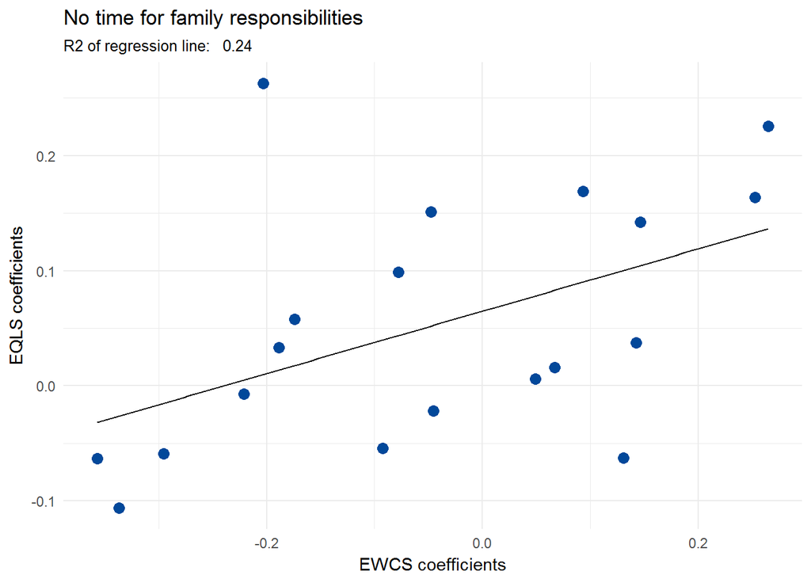

```r
df <- as.data.frame(cbind(glm_EWCS$fam_resp[-1,1],glm_EQLS$fam_resp[-1,1]))
ggplot(df, aes(x=V1,y=V2)) +
  geom_point(size=3,colour=EF_blue) +
  geom_smooth(method = "lm", se = F, colour="black", size=0.5) +
   labs(title = "No time for family responsibilities",
       subtitle = paste("R2 of regression line:  ", round(summary(lm(V2 ~ V1 , df))$r.squared,2)),
       x = "EWCS coefficients", y = "EQLS coefficients") +
    theme_minimal()
```

```r
kable(glm_EWCS$fam_resp,format="markdown")
```

|  | Estimate | Std. Error | t value | Pr(>\|t\|) |
| --- | --- | --- | --- | --- |
| (Intercept) | 1.1380719 | 0.0553525 | 20.5604504 | 0.0000000 |
| GenderFemale | -0.0455689 | 0.0227025 | -2.0072173 | 0.0447975 |
| empl_stat2employee | -0.2212868 | 0.0312916 | -7.0717537 | 0.0000000 |
| ISCOProfessionals | -0.1883729 | 0.0510754 | -3.6881345 | 0.0002291 |
| ISCOTechnicians and associate professionals | -0.2955086 | 0.0516929 | -5.7166145 | 0.0000000 |
| ISCOClerical support workers | -0.3368113 | 0.0593360 | -5.6763356 | 0.0000000 |
| ISCOService workers | -0.0922839 | 0.0558945 | -1.6510374 | 0.0988139 |
| ISCOSales workers | -0.0475120 | 0.0563618 | -0.8429828 | 0.3992913 |
| ISCOSkilled agricultural, forestry and fishery workers | -0.2031868 | 0.0702186 | -2.8936311 | 0.0038299 |
| ISCOCraft and related trades workers | -0.1742731 | 0.0535168 | -3.2564202 | 0.0011382 |
| ISCOPlant and machine operators and assemblers | -0.0781032 | 0.0563067 | -1.3871032 | 0.1654920 |
| ISCOElementary occupations | -0.3572754 | 0.0572229 | -6.2435777 | 0.0000000 |
| partner_childCouple, no children | 0.1467843 | 0.0278710 | 5.2665603 | 0.0000001 |
| partner_childSingle parent | 0.2526462 | 0.0472146 | 5.3510193 | 0.0000001 |
| partner_childCouple with children | 0.2652600 | 0.0334925 | 7.9199704 | 0.0000000 |
| education_3cat.L | 0.1307989 | 0.0433130 | 3.0198520 | 0.0025459 |
| education_3cat.Q | 0.0494238 | 0.0263874 | 1.8730043 | 0.0611448 |
| migrantBorn in another country | 0.0931707 | 0.0454311 | 2.0508149 | 0.0403537 |
| care_child_grandchild | 0.0672078 | 0.0086927 | 7.7315466 | 0.0000000 |
| care_disabled | 0.1427249 | 0.0238093 | 5.9945124 | 0.0000000 |

```r
kable(glm_EQLS$fam_resp,format="markdown")
```

|  | Estimate | Std. Error | t value | Pr(>\|t\|) |
| --- | --- | --- | --- | --- |
| (Intercept) | 1.3086391 | 0.0859942 | 15.2177685 | 0.0000000 |
| GenderFemale | -0.0216458 | 0.0367708 | -0.5886693 | 0.5561294 |
| empl_stat2employee | -0.0068703 | 0.0535018 | -0.1284122 | 0.8978317 |
| ISCOProfessionals | 0.0334290 | 0.0655703 | 0.5098194 | 0.6102171 |
| ISCOTechnicians and associate professionals | -0.0589314 | 0.0627798 | -0.9386994 | 0.3479640 |
| ISCOClerical support workers | -0.1060785 | 0.0693248 | -1.5301679 | 0.1260852 |
| ISCOService workers | -0.0541793 | 0.0680900 | -0.7957012 | 0.4262715 |
| ISCOSales workers | 0.1513393 | 0.0732210 | 2.0668820 | 0.0388346 |
| ISCOSkilled agricultural, forestry and fishery workers | 0.2626707 | 0.1011081 | 2.5979202 | 0.0094269 |
| ISCOCraft and related trades workers | 0.0576287 | 0.0700538 | 0.8226355 | 0.4107836 |
| ISCOPlant and machine operators and assemblers | 0.0984534 | 0.0937133 | 1.0505803 | 0.2935397 |
| ISCOElementary occupations | -0.0632012 | 0.0836173 | -0.7558392 | 0.4498075 |
| partner_childCouple, no children | 0.1422334 | 0.0426114 | 3.3379196 | 0.0008548 |
| partner_childSingle parent | 0.1634696 | 0.0865708 | 1.8882760 | 0.0590895 |
| partner_childCouple with children | 0.2253903 | 0.0542459 | 4.1549764 | 0.0000335 |
| education_3cat.L | -0.0626024 | 0.0900006 | -0.6955773 | 0.4867498 |
| education_3cat.Q | 0.0062185 | 0.0523151 | 0.1188662 | 0.9053896 |
| migrantBorn in another country | 0.1689169 | 0.0581580 | 2.9044462 | 0.0037071 |
| care_child_grandchild | 0.0158942 | 0.0133921 | 1.1868335 | 0.2353914 |
| care_disabled | 0.0375556 | 0.0373036 | 1.0067557 | 0.3141369 |

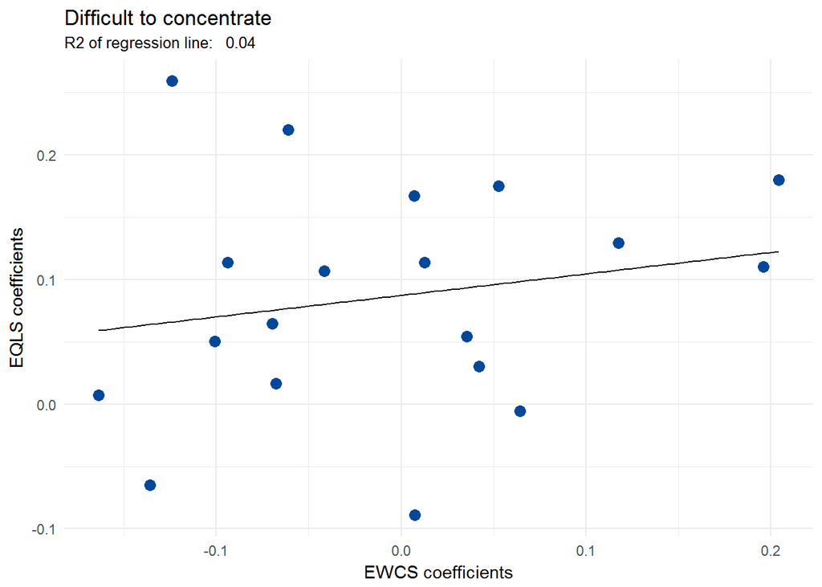

```r
df <- as.data.frame(cbind(glm_EWCS$concentrate[-1,1],glm_EQLS$concentrate[-1,1]))
ggplot(df, aes(x=V1,y=V2)) +
  geom_point(size=3,colour=EF_blue) +
  geom_smooth(method = "lm", se = F, colour="black", size=0.5) +
   labs(title = "Difficult to concentrate",
       subtitle = paste("R2 of regression line:  ", round(summary(lm(V2 ~ V1 , df))$r.squared,2)),
       x = "EWCS coefficients", y = "EQLS coefficients") +
    theme_minimal()
```

```r
kable(glm_EWCS$concentrate,format="markdown")
```

|  | Estimate | Std. Error | t value | Pr(>\|t\|) |
| --- | --- | --- | --- | --- |
| (Intercept) | 0.7190802 | 0.0470644 | 15.2786478 | 0.0000000 |
| GenderFemale | 0.0353359 | 0.0179564 | 1.9678749 | 0.0491553 |
| empl_stat2employee | -0.1359406 | 0.0241359 | -5.6322904 | 0.0000000 |
| ISCOProfessionals | -0.0697568 | 0.0428903 | -1.6264001 | 0.1039478 |
| ISCOTechnicians and associate professionals | -0.1006225 | 0.0441313 | -2.2800689 | 0.0226590 |
| ISCOClerical support workers | -0.0938887 | 0.0484297 | -1.9386605 | 0.0526169 |
| ISCOService workers | -0.0677573 | 0.0494388 | -1.3705285 | 0.1706032 |
| ISCOSales workers | 0.0069999 | 0.0479935 | 0.1458510 | 0.8840468 |
| ISCOSkilled agricultural, forestry and fishery workers | -0.1238091 | 0.0578389 | -2.1405862 | 0.0323711 |
| ISCOCraft and related trades workers | -0.0414805 | 0.0460953 | -0.8998876 | 0.3682373 |
| ISCOPlant and machine operators and assemblers | -0.0611799 | 0.0484790 | -1.2619863 | 0.2070315 |
| ISCOElementary occupations | -0.1637612 | 0.0477249 | -3.4313600 | 0.0006070 |
| partner_childCouple, no children | 0.0127097 | 0.0236680 | 0.5370003 | 0.5912989 |
| partner_childSingle parent | 0.2042461 | 0.0418194 | 4.8840029 | 0.0000011 |
| partner_childCouple with children | 0.1173880 | 0.0284679 | 4.1235167 | 0.0000381 |
| education_3cat.L | 0.0074135 | 0.0371096 | 0.1997722 | 0.8416695 |
| education_3cat.Q | 0.0641291 | 0.0220421 | 2.9093911 | 0.0036424 |
| migrantBorn in another country | 0.0528137 | 0.0432324 | 1.2216228 | 0.2219264 |
| care_child_grandchild | 0.0422277 | 0.0068265 | 6.1858888 | 0.0000000 |
| care_disabled | 0.1959666 | 0.0192218 | 10.1950248 | 0.0000000 |

```r
kable(glm_EQLS$concentrate,format="markdown")
```

|  | Estimate | Std. Error | t value | Pr(>\|t\|) |
| --- | --- | --- | --- | --- |
| (Intercept) | 0.7860705 | 0.0792895 | 9.9139264 | 0.0000000 |
| GenderFemale | 0.0542159 | 0.0308522 | 1.7572764 | 0.0789772 |
| empl_stat2employee | -0.0650630 | 0.0465629 | -1.3973164 | 0.1624263 |
| ISCOProfessionals | 0.0644070 | 0.0565239 | 1.1394639 | 0.2546047 |
| ISCOTechnicians and associate professionals | 0.0502369 | 0.0586665 | 0.8563125 | 0.3918964 |
| ISCOClerical support workers | 0.1136795 | 0.0611979 | 1.8575732 | 0.0633319 |
| ISCOService workers | 0.0163498 | 0.0619031 | 0.2641193 | 0.7917069 |
| ISCOSales workers | 0.1671539 | 0.0687004 | 2.4330860 | 0.0150314 |
| ISCOSkilled agricultural, forestry and fishery workers | 0.2592888 | 0.0961921 | 2.6955300 | 0.0070686 |
| ISCOCraft and related trades workers | 0.1070307 | 0.0694275 | 1.5416193 | 0.1232763 |
| ISCOPlant and machine operators and assemblers | 0.2200212 | 0.0898053 | 2.4499796 | 0.0143457 |
| ISCOElementary occupations | 0.0072894 | 0.0745207 | 0.0978175 | 0.9220840 |
| partner_childCouple, no children | 0.1135370 | 0.0395846 | 2.8682120 | 0.0041581 |
| partner_childSingle parent | 0.1799496 | 0.0781006 | 2.3040747 | 0.0212895 |
| partner_childCouple with children | 0.1292582 | 0.0481841 | 2.6825906 | 0.0073473 |
| education_3cat.L | -0.0888326 | 0.0944015 | -0.9410087 | 0.3467795 |
| education_3cat.Q | -0.0056305 | 0.0529373 | -0.1063625 | 0.9153022 |
| migrantBorn in another country | 0.1749824 | 0.0590534 | 2.9631201 | 0.0030704 |
| care_child_grandchild | 0.0304162 | 0.0110716 | 2.7472370 | 0.0060475 |
| care_disabled | 0.1101093 | 0.0357699 | 3.0782702 | 0.0021017 |

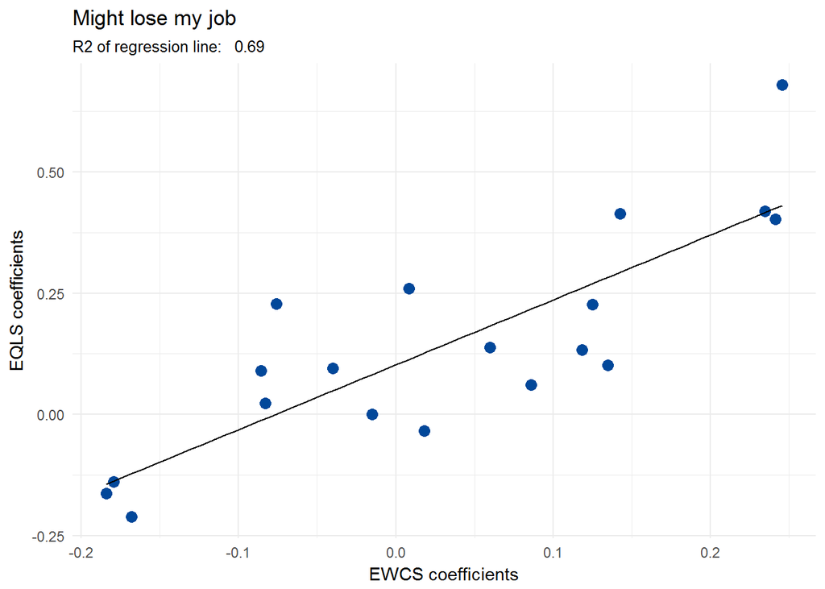

```r
df <- as.data.frame(cbind(glm_EWCS$mightlose[-1,1],glm_EQLS$mightlose[-1,1]))
ggplot(df, aes(x=V1,y=V2)) +
  geom_point(size=3,colour=EF_blue) +
  geom_smooth(method = "lm", se = F, colour="black", size=0.5) +
   labs(title = "Might lose my job",
       subtitle = paste("R2 of regression line:  ", round(summary(lm(V2 ~ V1 , df))$r.squared,2)),
       x = "EWCS coefficients", y = "EQLS coefficients") +
    theme_minimal()
```

```r
kable(glm_EWCS$mightlose,format="markdown")
```

|  | Estimate | Std. Error | t value | Pr(>\|t\|) |
| --- | --- | --- | --- | --- |
| (Intercept) | 1.0983654 | 0.0695295 | 15.7971151 | 0.0000000 |
| GenderFemale | 0.0180141 | 0.0259660 | 0.6937568 | 0.4878777 |
| empl_stat2employee | 0.0597166 | 0.0370252 | 1.6128638 | 0.1068581 |
| ISCOProfessionals | -0.0400804 | 0.0632239 | -0.6339441 | 0.5261559 |
| ISCOTechnicians and associate professionals | -0.0857978 | 0.0609650 | -1.4073296 | 0.1594124 |
| ISCOClerical support workers | 0.0084465 | 0.0668980 | 0.1262595 | 0.8995332 |
| ISCOService workers | 0.1250880 | 0.0646634 | 1.9344492 | 0.0531329 |
| ISCOSales workers | 0.2347187 | 0.0695012 | 3.3771883 | 0.0007398 |
| ISCOSkilled agricultural, forestry and fishery workers | -0.0758355 | 0.0960092 | -0.7898777 | 0.4296491 |
| ISCOCraft and related trades workers | 0.2414273 | 0.0655670 | 3.6821454 | 0.0002345 |
| ISCOPlant and machine operators and assemblers | 0.1423755 | 0.0708802 | 2.0086778 | 0.0446427 |
| ISCOElementary occupations | 0.2454694 | 0.0693056 | 3.5418404 | 0.0004022 |
| partner_childCouple, no children | -0.1793308 | 0.0361713 | -4.9578173 | 0.0000007 |
| partner_childSingle parent | -0.0829669 | 0.0576414 | -1.4393615 | 0.1501314 |
| partner_childCouple with children | -0.1840408 | 0.0416929 | -4.4142041 | 0.0000104 |
| education_3cat.L | -0.1680748 | 0.0537639 | -3.1261673 | 0.0017845 |
| education_3cat.Q | 0.0860111 | 0.0324859 | 2.6476432 | 0.0081394 |
| migrantBorn in another country | 0.1185043 | 0.0494061 | 2.3985766 | 0.0165074 |
| care_child_grandchild | -0.0150197 | 0.0100151 | -1.4996998 | 0.1337762 |
| care_disabled | 0.1348064 | 0.0310019 | 4.3483316 | 0.0000141 |

```r
kable(glm_EQLS$mightlose,format="markdown")
```

|  | Estimate | Std. Error | t value | Pr(>\|t\|) |
| --- | --- | --- | --- | --- |
| (Intercept) | 0.6472776 | 0.0789764 | 8.1958343 | 0.0000000 |
| GenderFemale | -0.0337725 | 0.0315742 | -1.0696216 | 0.2848795 |
| empl_stat2employee | 0.1387886 | 0.0417271 | 3.3261042 | 0.0008918 |
| ISCOProfessionals | 0.0955248 | 0.0603168 | 1.5837185 | 0.1133679 |
| ISCOTechnicians and associate professionals | 0.0902441 | 0.0633499 | 1.4245334 | 0.1544007 |
| ISCOClerical support workers | 0.2599616 | 0.0655605 | 3.9652150 | 0.0000751 |
| ISCOService workers | 0.2269299 | 0.0654788 | 3.4656995 | 0.0005366 |
| ISCOSales workers | 0.4190897 | 0.0742392 | 5.6451266 | 0.0000000 |
| ISCOSkilled agricultural, forestry and fishery workers | 0.2286250 | 0.0917960 | 2.4905757 | 0.0128097 |
| ISCOCraft and related trades workers | 0.4025809 | 0.0723542 | 5.5640296 | 0.0000000 |
| ISCOPlant and machine operators and assemblers | 0.4136546 | 0.0851386 | 4.8586046 | 0.0000012 |
| ISCOElementary occupations | 0.6797071 | 0.0850209 | 7.9945927 | 0.0000000 |
| partner_childCouple, no children | -0.1383320 | 0.0430376 | -3.2142159 | 0.0013225 |
| partner_childSingle parent | 0.0236067 | 0.0763674 | 0.3091196 | 0.7572530 |
| partner_childCouple with children | -0.1629670 | 0.0527191 | -3.0912304 | 0.0020124 |
| education_3cat.L | -0.2109427 | 0.0797608 | -2.6446912 | 0.0082211 |
| education_3cat.Q | 0.0610124 | 0.0470656 | 1.2963258 | 0.1949674 |
| migrantBorn in another country | 0.1330919 | 0.0639815 | 2.0801629 | 0.0375990 |
| care_child_grandchild | -0.0001947 | 0.0114914 | -0.0169465 | 0.9864805 |
| care_disabled | 0.1020548 | 0.0369335 | 2.7632009 | 0.0057602 |

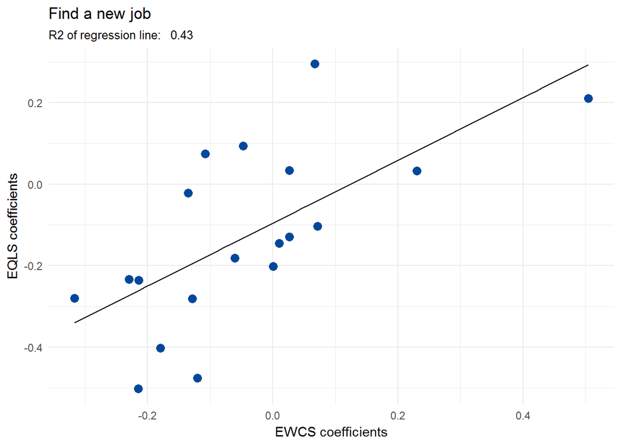

```r
df <- as.data.frame(cbind(glm_EWCS$findnewjob[-1,1],glm_EQLS$findnewjob[-1,1]))
ggplot(df, aes(x=V1,y=V2)) +
  geom_point(size=3,colour=EF_blue) +
  geom_smooth(method = "lm", se = F, colour="black", size=0.5) +
   labs(title = "Find a new job",
       subtitle = paste("R2 of regression line:  ", round(summary(lm(V2 ~ V1 , df))$r.squared,2)),
       x = "EWCS coefficients", y = "EQLS coefficients") +
    theme_minimal()
```

```r
kable(glm_EWCS$findnewjob,format="markdown")
```

|  | Estimate | Std. Error | t value | Pr(>\|t\|) |
| --- | --- | --- | --- | --- |
| (Intercept) | 1.7574274 | 0.0808704 | 21.7314058 | 0.0000000 |
| GenderFemale | -0.0472812 | 0.0289279 | -1.6344484 | 0.1022484 |
| empl_stat2employee | 0.0668296 | 0.0451699 | 1.4795152 | 0.1390864 |
| ISCOProfessionals | 0.0104951 | 0.0693816 | 0.1512657 | 0.8797743 |
| ISCOTechnicians and associate professionals | 0.0004830 | 0.0710372 | 0.0067991 | 0.9945755 |
| ISCOClerical support workers | -0.2151753 | 0.0718749 | -2.9937492 | 0.0027736 |
| ISCOService workers | 0.0712682 | 0.0724609 | 0.9835400 | 0.3254050 |
| ISCOSales workers | -0.0609682 | 0.0754121 | -0.8084679 | 0.4188724 |
| ISCOSkilled agricultural, forestry and fishery workers | -0.1796579 | 0.1121723 | -1.6016246 | 0.1093226 |
| ISCOCraft and related trades workers | 0.0264475 | 0.0738118 | 0.3583100 | 0.7201314 |
| ISCOPlant and machine operators and assemblers | -0.1203358 | 0.0784370 | -1.5341709 | 0.1250717 |
| ISCOElementary occupations | -0.2143620 | 0.0764481 | -2.8040213 | 0.0050728 |
| partner_childCouple, no children | -0.1286658 | 0.0386633 | -3.3278570 | 0.0008836 |
| partner_childSingle parent | -0.3174140 | 0.0614264 | -5.1673912 | 0.0000002 |
| partner_childCouple with children | -0.2297049 | 0.0454239 | -5.0569167 | 0.0000004 |
| education_3cat.L | 0.5046497 | 0.0578142 | 8.7288261 | 0.0000000 |
| education_3cat.Q | -0.1080943 | 0.0349266 | -3.0948983 | 0.0019833 |
| migrantBorn in another country | 0.2301941 | 0.0491782 | 4.6808147 | 0.0000030 |
| care_child_grandchild | 0.0264802 | 0.0115494 | 2.2927766 | 0.0219158 |
| care_disabled | -0.1352148 | 0.0326865 | -4.1367129 | 0.0000360 |

```r
kable(glm_EQLS$findnewjob,format="markdown")
```

|  | Estimate | Std. Error | t value | Pr(>\|t\|) |
| --- | --- | --- | --- | --- |
| (Intercept) | 2.0486153 | 0.1068651 | 19.1701054 | 0.0000000 |
| GenderFemale | 0.0941075 | 0.0422969 | 2.2249279 | 0.0261637 |
| empl_stat2employee | 0.2954189 | 0.0572754 | 5.1578661 | 0.0000003 |
| ISCOProfessionals | -0.1452609 | 0.0868864 | -1.6718482 | 0.0946634 |
| ISCOTechnicians and associate professionals | -0.2022819 | 0.0952488 | -2.1237205 | 0.0337790 |
| ISCOClerical support workers | -0.5020714 | 0.0979598 | -5.1252789 | 0.0000003 |
| ISCOService workers | -0.1032919 | 0.0959584 | -1.0764240 | 0.2818283 |
| ISCOSales workers | -0.1809991 | 0.0993869 | -1.8211575 | 0.0686872 |
| ISCOSkilled agricultural, forestry and fishery workers | -0.4023510 | 0.1486038 | -2.7075415 | 0.0068186 |
| ISCOCraft and related trades workers | -0.1291094 | 0.0943869 | -1.3678735 | 0.1714589 |
| ISCOPlant and machine operators and assemblers | -0.4760088 | 0.1167102 | -4.0785533 | 0.0000466 |
| ISCOElementary occupations | -0.2358209 | 0.1102481 | -2.1390013 | 0.0325199 |
| partner_childCouple, no children | -0.2816137 | 0.0534330 | -5.2704068 | 0.0000001 |
| partner_childSingle parent | -0.2796013 | 0.1059472 | -2.6390626 | 0.0083586 |
| partner_childCouple with children | -0.2333629 | 0.0732818 | -3.1844612 | 0.0014658 |
| education_3cat.L | 0.2107574 | 0.1053495 | 2.0005542 | 0.0455347 |
| education_3cat.Q | 0.0739885 | 0.0664636 | 1.1132182 | 0.2657081 |
| migrantBorn in another country | 0.0327447 | 0.0935324 | 0.3500890 | 0.7262976 |
| care_child_grandchild | 0.0335482 | 0.0166224 | 2.0182538 | 0.0436579 |
| care_disabled | -0.0213104 | 0.0462245 | -0.4610202 | 0.6448191 |

# Summary

[output not shown]